# CUNY New York City Collwge of Technology Alumni (Graduate)

[Credential](https://www.parchment.com/u/award/c50eccd5efef8571518ac5b61e2ea6b2)

Email

[LinkedIn](https://www.linkedin.com/in/le-sean-roberts/)

[GitHub](https://github.com/LeSeanRoberts/Major-Projects)

## Synopsis

This development explores the landscape of urban commuting based on Yellow Taxi service under supervision by the New York City Taxi and Limousine Commission (TLC). Instances to for use is the 2023 Yellow Taxi trip data set, constituted by millions of records (instances). The study begins with data assimilation via SODA/Socrata type API, followed by charactersisation of the data, then meticulous data wrangling to address any natural data integrity issues, or to engineer attributes of interest. Conventional data analysis, unsuperised learining and supervised (or ensemble) learning to apply.

## Introduction

This project represents an end-to-end journey from raw data to predictive intelligence. The development phase began with extensive data wrangling, encompassing both strategic feature engineering and the resolution of unforeseen data quality issues. These efforts paved the way for a deep dive into the dataset through descriptive statistics and unsupervised learning, revealing hidden structures and trends.

Building upon this analytical foundation, there's implementation advanced tree-based predictive models—culminating in both a high-performing Random Forest regressor and LightGBM regressor. While a dataset may initially appear uninspiring, this work demonstrates that with knowledge, imagination, and a curious mindset, even simple observations can be transformed into advanced, actionable insights.

## Data Assimilation and Data Wrangling

From NYC Open Data API repository the 2023 Yellow Taxi trip data set is accessed via the Socrata Open Data API. Records stem from the trip record submissions made by yellow taxi Technology Service Providers (TSPs). Each row represents a single trip in a yellow taxi. The trip records include fields capturing pick-up and drop-off dates/times, pick-up and drop-off taxi zone locations, trip distances, itemized fares, rate types, payment types, and driver-reported passenger counts.

The data dictionary for such data set:

```python
from IPython.display import HTML

# Defining the HTML content as a string
yellow_taxi_data_dictionary_table = """
<div style="overflow-x:auto;">
    <h2 style="color: #2c3e50; font-family: sans-serif;">NYC Yellow Taxi Trip Data: Column Specifications</h2>
    <table style="border-collapse: collapse; width: 100%; font-family: sans-serif; border: 1px solid #ddd;">
        <thead>
            <tr style="background-color: #f4b400; color: white;">
                <th style="padding: 12px; text-align: left; border: 1px solid #ddd;">Column Name</th>
                <th style="padding: 12px; text-align: left; border: 1px solid #ddd;">Description</th>
                <th style="padding: 12px; text-align: left; border: 1px solid #ddd;">API Field Name</th>
                <th style="padding: 12px; text-align: left; border: 1px solid #ddd;">Data Type</th>
            </tr>
        </thead>
        <tbody>
            <tr style="background-color: #ffffff;"><td><strong>VendorID</strong></td><td>A code indicating the TPEP provider that provided the record.
1 = Creative Mobile Technologies, LLC;
2 = Curb Mobility, LLC;
6 = Myle Technologies Inc;
7 = Helix</td><td>vendorid</td><td>Number</td></tr>
            <tr style="background-color: #f9f9f9;"><td><strong>tpep_pickup_datetime</strong></td><td>Date and time when the meter was engaged.</td><td>tpep_pickup_datetime</td><td>Timestamp</td></tr>
            <tr style="background-color: #ffffff;"><td><strong>tpep_dropoff_datetime</strong></td><td>Date and time when the meter was disengaged.</td><td>tpep_dropoff_datetime</td><td>Timestamp</td></tr>
            <tr style="background-color: #f9f9f9;"><td><strong>passenger_count</strong></td><td>Number of passengers in the vehicle.</td><td>passenger_count</td><td>Number</td></tr>
            <tr style="background-color: #ffffff;"><td><strong>trip_distance</strong></td><td>Elapsed trip distance in miles.</td><td>trip_distance</td><td>Number</td></tr>
            <tr style="background-color: #f9f9f9;"><td><strong>RatecodeID</strong></td><td>Final rate code in effect. The final rate code in effect at the end of the trip. 1 = Standard rate;
            2 = JFK;
            3 = Newark;
            4 = Nassau or Westchester;
            5 = Negotiated fare;
            6 = Group ride;
            99 = Null/unknown</td><td>ratecodeid</td><td>Number</td></tr>
            <tr style="background-color: #ffffff;"><td><strong>store_and_fwd_flag</strong></td><td>This flag indicates whether the trip record was held in vehicle memory before
sending to the vendor, aka “store and forward,” because the vehicle did not have a connection to the server. Y = store and forward trip; N = not a store and forward trip.</td><td>store_and_fwd_flag</td><td>Text</td></tr>
            <tr style="background-color: #f9f9f9;"><td><strong>PULocationID</strong></td><td>TLC Taxi Zone (Pickup).</td><td>pulocationid</td><td>Number</td></tr>
            <tr style="background-color: #ffffff;"><td><strong>DOLocationID</strong></td><td>TLC Taxi Zone (Drop-off).</td><td>dolocationid</td><td>Number</td></tr>
            <tr style="background-color: #f9f9f9;"><td><strong>payment_type</strong></td><td>A numeric code signifying how the passenger paid for the trip.
            0 = Flex Fare trip;
            1 = Credit card;
            2 = Cash;
            3 = No charge;
            4 = Dispute;
            5 = Unknown;
            6 = Voided trip</td><td>payment_type</td><td>Number</td></tr>
            <tr style="background-color: #ffffff;"><td><strong>fare_amount</strong></td><td>Time-and-distance fare.</td><td>fare_amount</td><td>Number</td></tr>
            <tr style="background-color: #f9f9f9;"><td><strong>extra</strong></td><td>Miscellaneous extras and surcharges.</td><td>extra</td><td>Number</td></tr>
            <tr style="background-color: #ffffff;"><td><strong>mta_tax</strong></td><td>Tax that is automatically triggered based on the metered rate in use.</td><td>mta_tax</td><td>Number</td></tr>
            <tr style="background-color: #f9f9f9;"><td><strong>tip_amount</strong></td><td>Credit card tips only.</td><td>tip_amount</td><td>Number</td></tr>
            <tr style="background-color: #ffffff;"><td><strong>tolls_amount</strong></td><td>Total amount of all tolls.</td><td>tolls_amount</td><td>Number</td></tr>
            <tr style="background-color: #f9f9f9;"><td><strong>improvement_surcharge</strong></td><td>Surcharge assessed at flag drop.</td><td>improvement_surcharge</td><td>Number</td></tr>
            <tr style="background-color: #ffffff;"><td><strong>total_amount</strong></td><td>Total charged (excluding cash tips).</td><td>total_amount</td><td>Number</td></tr>
            <tr style="background-color: #f9f9f9;"><td><strong>congestion_surcharge</strong></td><td>NYS congestion surcharge.</td><td>congestion_surcharge</td><td>Number</td></tr>
            <tr style="background-color: #ffffff;"><td><strong>airport_fee</strong></td><td>Pick up fee only at LaGuardia and John F. Kennedy Airports.</td><td>airport_fee</td><td>Number</td></tr>
        </tbody>
    </table>
</div>
"""

# Display the HTML
HTML(yellow_taxi_data_dictionary_table)
```

NYC Yellow Taxi Trip Data: Column Specifications

| Column Name | Description | API Field Name | Data Type |
| --- | --- | --- | --- |
| **VendorID** | A code indicating the TPEP provider that provided the record. 1 = Creative Mobile Technologies, LLC; 2 = Curb Mobility, LLC; 6 = Myle Technologies Inc; 7 = Helix | vendorid | Number |
| **tpep_pickup_datetime** | Date and time when the meter was engaged. | tpep_pickup_datetime | Timestamp |
| **tpep_dropoff_datetime** | Date and time when the meter was disengaged. | tpep_dropoff_datetime | Timestamp |
| **passenger_count** | Number of passengers in the vehicle. | passenger_count | Number |
| **trip_distance** | Elapsed trip distance in miles. | trip_distance | Number |
| **RatecodeID** | Final rate code in effect. The final rate code in effect at the end of the trip. 1 = Standard rate; 2 = JFK; 3 = Newark; 4 = Nassau or Westchester; 5 = Negotiated fare; 6 = Group ride; 99 = Null/unkno… | ratecodeid | Number |
| **store_and_fwd_flag** | This flag indicates whether the trip record was held in vehicle memory before sending to the vendor, aka “store and forward,” because the vehicle did not have a connection to the server. Y = store and… | store_and_fwd_flag | Text |
| **PULocationID** | TLC Taxi Zone (Pickup). | pulocationid | Number |
| **DOLocationID** | TLC Taxi Zone (Drop-off). | dolocationid | Number |
| **payment_type** | A numeric code signifying how the passenger paid for the trip. 0 = Flex Fare trip; 1 = Credit card; 2 = Cash; 3 = No charge; 4 = Dispute; 5 = Unknown; 6 = Voided trip | payment_type | Number |
| **fare_amount** | Time-and-distance fare. | fare_amount | Number |
| **extra** | Miscellaneous extras and surcharges. | extra | Number |
| **mta_tax** | Tax that is automatically triggered based on the metered rate in use. | mta_tax | Number |
| **tip_amount** | Credit card tips only. | tip_amount | Number |
| **tolls_amount** | Total amount of all tolls. | tolls_amount | Number |
| **improvement_surcharge** | Surcharge assessed at flag drop. | improvement_surcharge | Number |
| **total_amount** | Total charged (excluding cash tips). | total_amount | Number |
| **congestion_surcharge** | NYS congestion surcharge. | congestion_surcharge | Number |
| **airport_fee** | Pick up fee only at LaGuardia and John F. Kennedy Airports. | airport_fee | Number |

Observing the entire NYC Taxi Location ID description:

```python
import pandas as pd

# This removes the limit on displayed rows
pd.set_option('display.max_rows', None)

# Load the lookup table directly from the URL
url = "https://d37ci6vzurychx.cloudfront.net/misc/taxi_zone_lookup.csv"
zones_df = pd.read_csv(url)

# Display the first few rows
print(zones_df)
```

```
     LocationID        Borough                                           Zone  \
0             1            EWR                                 Newark Airport
1             2         Queens                                    Jamaica Bay
2             3          Bronx                        Allerton/Pelham Gardens
3             4      Manhattan                                  Alphabet City
4             5  Staten Island                                  Arden Heights
5             6  Staten Island                        Arrochar/Fort Wadsworth
6             7         Queens                                        Astoria
7             8         Queens                                   Astoria Park
8             9         Queens                                     Auburndale
9            10         Queens                                   Baisley Park
10           11       Brooklyn                                     Bath Beach
11           12      Manhattan                                   Battery Park
12           13      Manhattan                              Battery Park City
13           14       Brooklyn                                      Bay Ridge
```

[output cut: 518 more lines]

```python
zones_df.info()
```

```
<class 'pandas.core.frame.DataFrame'>
RangeIndex: 265 entries, 0 to 264
Data columns (total 4 columns):
 #   Column        Non-Null Count  Dtype
---  ------        --------------  -----
 0   LocationID    265 non-null    int64
 1   Borough       264 non-null    object
 2   Zone          264 non-null    object
 3   service_zone  263 non-null    object
dtypes: int64(1), object(3)
memory usage: 8.4+ KB
```

Concerning the above location codes, there will be no collapsing of class instances in general borough instances, because NYC boroughs are quite big. Hence, a general location within a borough isn't highly insightful with taxi journeys.

Data assimilation:

```python
from sodapy import Socrata
import pandas as pd

client = Socrata("data.cityofnewyork.us", None)

limit = 50000          # page size
max_rows = 80000      # total rows you want
offset = 0
collected = 0
dfs = []

while collected < max_rows:
    remaining = max_rows - collected
    batch_limit = min(limit, remaining)  # don't overfetch

    results = client.get("4b4i-vvec", limit=batch_limit, offset=offset)

    if not results:
        break

    df = pd.DataFrame.from_records(results)
    dfs.append(df)

    rows = len(df)
    collected += rows
    offset += rows

    print(f"Fetched {collected} rows")

full_df = pd.concat(dfs, ignore_index=True)
print(full_df.shape)
```

```
WARNING:root:Requests made without an app_token will be subject to strict throttling limits.
```

```
Fetched 50000 rows
Fetched 80000 rows
(80000, 19)
```

One should be aware that Socrata returns everything as Strings (JSON) by default.

```python
# Checking the data's attributes and counts
full_df.info()
```

```
<class 'pandas.core.frame.DataFrame'>
RangeIndex: 80000 entries, 0 to 79999
Data columns (total 19 columns):
 #   Column                 Non-Null Count  Dtype
---  ------                 --------------  -----
 0   vendorid               80000 non-null  object
 1   tpep_pickup_datetime   80000 non-null  object
 2   tpep_dropoff_datetime  80000 non-null  object
 3   passenger_count        80000 non-null  object
 4   trip_distance          80000 non-null  object
 5   ratecodeid             80000 non-null  object
 6   store_and_fwd_flag     80000 non-null  object
 7   pulocationid           80000 non-null  object
 8   dolocationid           80000 non-null  object
 9   payment_type           80000 non-null  object
 10  fare_amount            80000 non-null  object
 11  extra                  80000 non-null  object
 12  mta_tax                80000 non-null  object
 13  tip_amount             80000 non-null  object
 14  tolls_amount           80000 non-null  object
 15  improvement_surcharge  80000 non-null  object
 16  total_amount           80000 non-null  object
 17  congestion_surcharge   80000 non-null  object
 18  airport_fee            80000 non-null  object
dtypes: object(19)
memory usage: 11.6+ MB
```

Observed are no missung values for any column in the data set. Furthemore, a decent peek of the true characteristics of the the data can be acquired:

```python
print(full_df.head(20))
```

```
   vendorid     tpep_pickup_datetime    tpep_dropoff_datetime passenger_count  \
0         2  2023-01-01T00:32:10.000  2023-01-01T00:40:36.000             1.0
1         2  2023-01-01T00:55:08.000  2023-01-01T01:01:27.000             1.0
2         2  2023-01-01T00:25:04.000  2023-01-01T00:37:49.000             1.0
3         1  2023-01-01T00:03:48.000  2023-01-01T00:13:25.000             0.0
4         2  2023-01-01T00:10:29.000  2023-01-01T00:21:19.000             1.0
5         2  2023-01-01T00:50:34.000  2023-01-01T01:02:52.000             1.0
6         2  2023-01-01T00:09:22.000  2023-01-01T00:19:49.000             1.0
7         2  2023-01-01T00:27:12.000  2023-01-01T00:49:56.000             1.0
8         2  2023-01-01T00:21:44.000  2023-01-01T00:36:40.000             1.0
9         2  2023-01-01T00:39:42.000  2023-01-01T00:50:36.000             1.0
10        2  2023-01-01T00:53:01.000  2023-01-01T01:01:45.000             1.0
11        1  2023-01-01T00:43:37.000  2023-01-01T01:17:18.000             4.0
12        2  2023-01-01T00:34:44.000  2023-01-01T01:04:25.000             1.0
13        2  2023-01-01T00:09:29.000  2023-01-01T00:29:23.000             2.0
```

[output cut: 72 more lines]

Based on the conveyed data dictionary, to now pursue wrangling (or attribute engineering) for pending interests in data analysis and machine learning techniques.

```python
import pandas as pd

# -------------------------
# datetime (floating timestamp)
# -------------------------
full_df["tpep_pickup_datetime"] = pd.to_datetime(
    full_df["tpep_pickup_datetime"],
    errors="coerce"
)

full_df["tpep_dropoff_datetime"] = pd.to_datetime(
    full_df["tpep_dropoff_datetime"],
    errors="coerce"
)


# -------------------------
# numeric
# -------------------------
numeric_cols = [
    "vendorid",
    "passenger_count",
    "trip_distance",
    "ratecodeid",
    "pulocationid",
    "dolocationid",
    "payment_type",
    "fare_amount",
    "extra",
    "mta_tax",
    "tip_amount",
    "tolls_amount",
    "improvement_surcharge",
    "total_amount",
    "congestion_surcharge",
    "airport_fee"
]

full_df[numeric_cols] = full_df[numeric_cols].apply(
    pd.to_numeric, errors="coerce"
)


# -------------------------
# categorical flag
# -------------------------
full_df["store_and_fwd_flag"] = (
    full_df["store_and_fwd_flag"]
        .astype("category")
)


# -------------------------
# optional memory optimization
# -------------------------
full_df = full_df.astype({
    "vendorid": "int8",
    "passenger_count": "int8",
    "ratecodeid": "int8",
    "payment_type": "int8",
    "pulocationid": "int16",
    "dolocationid": "int16"
})

print(full_df.info(memory_usage="deep"))
```

```
<class 'pandas.core.frame.DataFrame'>
RangeIndex: 80000 entries, 0 to 79999
Data columns (total 19 columns):
 #   Column                 Non-Null Count  Dtype
---  ------                 --------------  -----
 0   vendorid               80000 non-null  int8
 1   tpep_pickup_datetime   80000 non-null  datetime64[ns]
 2   tpep_dropoff_datetime  80000 non-null  datetime64[ns]
 3   passenger_count        80000 non-null  int8
 4   trip_distance          80000 non-null  float64
 5   ratecodeid             80000 non-null  int8
 6   store_and_fwd_flag     80000 non-null  category
 7   pulocationid           80000 non-null  int16
 8   dolocationid           80000 non-null  int16
 9   payment_type           80000 non-null  int8
 10  fare_amount            80000 non-null  float64
 11  extra                  80000 non-null  float64
 12  mta_tax                80000 non-null  float64
 13  tip_amount             80000 non-null  float64
 14  tolls_amount           80000 non-null  float64
 15  improvement_surcharge  80000 non-null  float64
 16  total_amount           80000 non-null  float64
 17  congestion_surcharge   80000 non-null  float64
 18  airport_fee            80000 non-null  float64
dtypes: category(1), datetime64[ns](2), float64(10), int16(2), int8(4)
memory usage: 8.0 MB
None
```

To now calculate the trip duration from the 'tpep_pickup_datetime' and 'tpep_dropoff_datetime' columns by computing the difference. As well, to express the duration in minutes because such matches taxi business metrics. Computing trip duration in minutes from the pickup and dropoff timestamps isn’t just a convenience step — it’s a core analytical feature that turns raw timestamps into something directly interpretable, comparable, and model-ready. Additionally, the data applied may also often contain "foul" temporal records. Additionally, taxi commutes for at least 1 hour may not be customary. The model: $$\Delta\,t_{trip}\,=\,\frac{T_{dropoff}-T_{pickup}}{60}$$ By creating this column, one can now mathematically identify possible anomalies. Anomalies of consideration (**but not necessarily implausible**):

1. **Zero-length trips** ($\Delta\,t_{trip}=0$)
2. **Negative durations:** Where the drop-off occurs before the pickup due to system errors.
3. **Extreme Outliers:** Trips lasting $>24$ hours that are likely meter errors.

   ```
   Shift-End to Shift-Start (The 24-Hour Cycle). NYC taxi shifts are typically 12 hours. If a record shows exactly 1440 minutes, it’s often a sign of a system reset or a driver logging out at the exact same time they logged in the previous day, causing the software to default to a 24-hour delta.
   ```

```python
# Compute duration in minutes (once)
full_df["trip_minutes"] = (
    full_df["tpep_dropoff_datetime"] -
    full_df["tpep_pickup_datetime"]
).dt.total_seconds().floordiv(60).astype("int32")  # integer minutes


# move column after dropoff
cols = list(full_df.columns)

cols.insert(
    cols.index("tpep_dropoff_datetime") + 1,
    cols.pop(cols.index("trip_minutes"))
)

full_df = full_df[cols]

full_df.info()
```

```
<class 'pandas.core.frame.DataFrame'>
RangeIndex: 80000 entries, 0 to 79999
Data columns (total 20 columns):
 #   Column                 Non-Null Count  Dtype
---  ------                 --------------  -----
 0   vendorid               80000 non-null  int8
 1   tpep_pickup_datetime   80000 non-null  datetime64[ns]
 2   tpep_dropoff_datetime  80000 non-null  datetime64[ns]
 3   trip_minutes           80000 non-null  int32
 4   passenger_count        80000 non-null  int8
 5   trip_distance          80000 non-null  float64
 6   ratecodeid             80000 non-null  int8
 7   store_and_fwd_flag     80000 non-null  category
 8   pulocationid           80000 non-null  int16
 9   dolocationid           80000 non-null  int16
 10  payment_type           80000 non-null  int8
 11  fare_amount            80000 non-null  float64
 12  extra                  80000 non-null  float64
 13  mta_tax                80000 non-null  float64
 14  tip_amount             80000 non-null  float64
 15  tolls_amount           80000 non-null  float64
 16  improvement_surcharge  80000 non-null  float64
 17  total_amount           80000 non-null  float64
 18  congestion_surcharge   80000 non-null  float64
 19  airport_fee            80000 non-null  float64
dtypes: category(1), datetime64[ns](2), float64(10), int16(2), int32(1), int8(4)
memory usage: 8.3 MB
```

For each column or atribute observing the number of unique values, and a sample of those values:

```python
# Identifying unique values for trip duration

time_duration_unique = full_df['trip_minutes'].unique()
print(time_duration_unique)
```

```
[   8    6   12    9   10   22   14   33   29   19   15   30    7   17
    2    5   27   32   16   28    3   11   37   13   39    4   68   20
    0   36   18    1   31   35   38   41   21   24   40   26   25   42
   23   44   45   34 1421   52 1376   58 1406   46   60   67   43   56
 1437   49   51   54   48 1415   64   47 1423 1427 1435 1416   55   50
   59   77   75   62 1407   89   69 1429   70   63 1438   53 1434 1432
   66 1433 1439 1418 1276   87 1393   61 1422 1288 1417 1436  420 1248
  826   71   72   57 1155 1419  202 1430 1409 1420 1336  991 1424  518
 1410 1364  854  812   78   93  107 1383  245 1351   74 1397   83  159
 1426 1412 1400  589   73   84 1413 1404   90   79 1387 1398 1431   82
   65  506  112 1428  870  878 1401   81 1411  101 1425   80   96  131
  193  113   76  124   92  467 1366  220  367  129  145  362  141   85
 1044   86  348   91 2596  307  119 1405  207 1378 1399  495 1392  120
 1391   94 1386 1414 1223 1235  109  128]
```

Unique values often coincide with anomalies or outliers. Many cases greatly surpass 180 minutes or 3 hours. Concerning New York City's yellow taxi system, the 3-hour mark can be considered a critical "tipping point" for data integrity, or driver safety, or economic logic.

1. The "Data Cleanliness" Standard

   ```
   System Errors: Occasionally, a driver forgets to turn off the meter, or a GPS glitch keeps a trip "active" for days.

   In a city where you can cross multiple boroughs in under an hour, a 3-hour trip is statistically an outlier that usually indicates a technical error rather than a real passenger.
   ```

2. Driver Fatigue & Legal Limits

   ```
   The TLC has strict Fatigued Driving Prevention rules (effective since 2017) to keep the roads safe. Specifically, TLC Rule §80-14

         10-Hour Rule: Drivers are prohibited from transporting passengers for more than 10 hours in any 24-hour period.

   Return Trip: A 3-hour trip away from the city centre often means a 3-hour return trip empty. Since drivers aren't paid for the return leg and that time still counts toward their physical exhaustion, 3 hours is the practical limit where a driver can still return and complete a standard shift without violating safety protocols.
   ```

3. The Geometry of NYC. Geographically, it's tedious to remain in a moving yellow taxi for more than 3 hours sansleaving the "Mandatory Service Area."

   ```
   Drivers are required to take you anywhere in the five boroughs, Westchester, Nassau, or to Newark Airport.

   Under TLC Rule §80-19, a driver can legally refuse a trip that they "reasonably believe" will take them past their daily shift limit. A 3-hour trip almost always triggers this safety refusal.

   Practicality: Even in heavy traffic, a trip from the southernmost point of Staten Island to the northernmost point of the Bronx rarely exceeds 2.5 hours. Beyond the 3-hour mark, one is likely heading deep into New Jersey or Upstate New York, where drivers have the legal right to refuse the fare if it would push them past a 12-hour consecutive work limit.
   ```

4. Diminishing Economic Returns

   ```
   Based on the 2023 data set Yellow taxis use a metered rate ($0.50 per 1/5 mile or per minute in slow traffic).

   The "Limo" Threshold: At the 3-hour mark, the meter cost (plus surcharges, tolls, and the necessary 20% tip for such a long haul) typically exceeds the cost of a private black car or a pre-arranged limousine service.

   Flat Rates: For specific long distances (like JFK to Manhattan), flat rates exist. For everything else, the meter becomes prohibitively expensive after 3 hours, making it "ideal" only for the most desperate or wealthy commuters.
   ```

Thorough observation for negative and/or 0 time durations, where the former isn't meaningful, and the latter isn't practical:

```python
# Checking for anomalies (negative time or 0)
print(f"Negative duration count: {(full_df['trip_minutes'] < 0).sum()}")
print(f"Zero duration count: {(full_df['trip_minutes'] == 0).sum()}")
```

```
Negative duration count: 0
Zero duration count: 1407
```

To now filter out the zero minutes trip duration cases:

```python
# Filter the dataframe to keep only positive durations
full_df = full_df[full_df['trip_minutes'] > 0]

# 3. Verify the change
print(f"New row count: {len(full_df)}")
```

```
New row count: 78593
```

**Statistical Distribution (The "Long Tail")**

If to plot a histogram of the trip_duration_minutes,one would observe a right-skewed distribution. Trips between 5 and 30 minutes may be deems customary. By 60 minutes (or 1 hour), the frequency drops to nearly zero. A duration of 80 minutes (1 hour and 20 minutes) appears to be a practical cutoff in statistical terms **for this particular data set**.

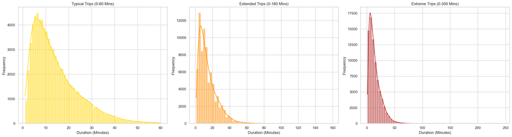

```python
import matplotlib.pyplot as plt
import seaborn as sns

# Set the visual style
sns.set_theme(style="whitegrid")

# Change: Initialized 3 subplots instead of 2 and increased width for readability
fig, (ax1, ax2, ax3) = plt.subplots(1, 3, figsize=(22, 6))

# Plot 1: Typical NYC Trips (0 - 60 minutes)
sns.histplot(full_df[full_df['trip_minutes'] <= 60]['trip_minutes'],
             bins=60, kde=True, color='gold', ax=ax1)
ax1.set_title('Typical Trips (0-60 Mins)')
ax1.set_xlabel('Duration (Minutes)')
ax1.set_ylabel('Frequency')

# Plot 2: Extended NYC Trips (0 - 180 minutes)
sns.histplot(full_df[full_df['trip_minutes'] <= 180]['trip_minutes'],
             bins=60, kde=True, color='darkorange', ax=ax2)
ax2.set_title('Extended Trips (0-180 Mins)')
ax2.set_xlabel('Duration (Minutes)')
ax2.set_ylabel('Frequency')

# Plot 3: Extreme NYC Trips (0 - 300 minutes)
# Change: Fixed 'ax' target and used a different color for distinction
sns.histplot(full_df[full_df['trip_minutes'] <= 300]['trip_minutes'],
             bins=60, kde=True, color='firebrick', ax=ax3)
ax3.set_title('Extreme Trips (0-300 Mins)')
ax3.set_xlabel('Duration (Minutes)')
ax3.set_ylabel('Frequency')

plt.tight_layout()
plt.show()
```

**"Cutoff" Choice and Data Loss**

```python
# 1. Calculating the counts
count_300 = (full_df['trip_minutes'] > 300).sum()
count_180 = (full_df['trip_minutes'] > 180).sum()
count_80  = (full_df['trip_minutes'] > 80).sum()
count_60  = (full_df['trip_minutes'] > 60).sum()

# 2. Corrected Print Statements
print(f"{'Threshold':<25} | {'Count':<10}")
print("-" * 40)
print(f"Trips > 5.0 hrs (300 min): | {count_300}")
print(f"Trips > 3.0 hrs (180 min): | {count_180}")
print(f"Trips > 1.33 hrs (80 min): | {count_80}")
print(f"Trips > 1.0 hr  (60 min): | {count_60}")

print("\n" + "="*40)
print("MARGINAL DATA LOSS ANALYSIS")
print("="*40)

# 3. Step-by-step differences
print(f"Loss by moving 300 -> 180 mins: {count_180 - count_300} trips")
print(f"Loss by moving 180 -> 80 mins:  {count_80 - count_180} trips")
print(f"Loss by moving 80  -> 60 mins:  {count_60 - count_80} trips")
```

```
Threshold                 | Count
----------------------------------------
Trips > 5.0 hrs (300 min): | 147
Trips > 3.0 hrs (180 min): | 152
Trips > 1.33 hrs (80 min): | 199
Trips > 1.0 hr  (60 min): | 424

========================================
MARGINAL DATA LOSS ANALYSIS
========================================
Loss by moving 300 -> 180 mins: 5 trips
Loss by moving 180 -> 80 mins:  47 trips
Loss by moving 80  -> 60 mins:  225 trips
```

**THE ELABORATION**

**The "Phantom" Outliers(300 to 180 mins)**

```
Loss: 5 trips. There are only 5 trips in this massive 2-hour window is a large red flag for those specific records. Such are almost certainly system errors or "forgotten meters." Dropping these has zero impact on any future model's statistical power, but considerably protects any Supervised Learning model from "long-tail" variance.
```

**The "Regional" Buffer (180 to 80 mins)**

```
Loss: 47 trips. Observed is a slight "thickening" of data here. These are likely legitimate but rare trips, such as travel to deep Long Island, Connecticut, or New Jersey during peak traffic. 47 trips out of ~78,000 is around 0.06% of the data, one can safely argue that removing them simplifies the model without losing the "essence" of NYC urban mobility.
```

**The "Knee Jerker" (80 to 60 mins)**

```
Loss: 225 trips. Observed now, the loss jumped from 47 to 225. This is the "knee" of the distribution curve. At 60–80 minutes, this is standard heavy traffic activity (e.g., Midtown to JFK at 5:00 PM). If to filter at 60 minutes, one is actually starting to eliminate "real" NYC traffic patterns. If tofilter at 80 or 180, one keeps these valuable high-congestion examples for supervised or ensemble learning models.
```

**Justification for Final Cutoff**

$$\text{Data Retention}\,\approx\,\frac{N-152}{N}\,\times\,100\%$$

```python
# Identify extreme duration outliers (trips at least 3 hours are rare in NYC)
MAX_DURATION = 180 # 3 hours is a safe upper limit for NYC traffic and other inhibitors

outliers = full_df[full_df['trip_minutes'] > MAX_DURATION]
print(f"Number of extreme duration outliers: {len(outliers)}")

# Data Wrangling: Filter them out for the learning phase
full_dff = full_df[full_df['trip_minutes'] <= MAX_DURATION]
```

```
Number of extreme duration outliers: 152
```

Now, to observe the unique values and samples for the other attributes to catch residing noise:

```python
for col in df.columns:
    unique_count = full_df[col].nunique()
    unique_vals = full_df[col].unique()

    print(f"Column: {col}")
    print(f"Count of Unique Values: {unique_count}")
    # Show first 5 values to avoid cluttering the screen
    print(f"Sample Values: {unique_vals[:5]}")
    print("-" * 30)
```

```
Column: vendorid
Count of Unique Values: 2
Sample Values: [2 1]
------------------------------
Column: tpep_pickup_datetime
Count of Unique Values: 51542
Sample Values: <DatetimeArray>
['2023-01-01 00:32:10', '2023-01-01 00:55:08', '2023-01-01 00:25:04',
 '2023-01-01 00:03:48', '2023-01-01 00:10:29']
Length: 5, dtype: datetime64[ns]
------------------------------
Column: tpep_dropoff_datetime
Count of Unique Values: 51881
Sample Values: <DatetimeArray>
['2023-01-01 00:40:36', '2023-01-01 01:01:27', '2023-01-01 00:37:49',
 '2023-01-01 00:13:25', '2023-01-01 00:21:19']
Length: 5, dtype: datetime64[ns]
------------------------------
Column: passenger_count
Count of Unique Values: 7
Sample Values: [1 0 4 2 3]
------------------------------
Column: trip_distance
Count of Unique Values: 2581
Sample Values: [0.97 1.1  2.51 1.9  1.43]
------------------------------
Column: ratecodeid
Count of Unique Values: 6
Sample Values: [ 1  2  4 99  5]
------------------------------
Column: store_and_fwd_flag
Count of Unique Values: 2
Sample Values: ['N', 'Y']
Categories (2, object): ['N', 'Y']
------------------------------
Column: pulocationid
Count of Unique Values: 222
Sample Values: [161  43  48 138 107]
------------------------------
Column: dolocationid
```

[output cut: 28 more lines]

```
Count of Unique Values: 5
Sample Values: [ 1.  -1.   0.3 -0.3  0. ]
------------------------------
Column: total_amount
Count of Unique Values: 4925
Sample Values: [14.3  16.9  34.9  20.85 19.68]
------------------------------
Column: congestion_surcharge
Count of Unique Values: 3
Sample Values: [ 2.5  0.  -2.5]
------------------------------
Column: airport_fee
Count of Unique Values: 3
Sample Values: [ 0.    1.25 -1.25]
------------------------------
```

From above, aside from the observation of unique values for each collumn (attribute), there's also notice of negative values in the provided samples.

How does one get negative airport fees with a taxi? Concerning the 2023 Yellow Taxi Trip Data, observing a negative value in the airport_fee (or any other fare-related column) is almost always a sign of a voided trip or a correction record.

1. **The "Refund" or "Correction" Logic**

The NYC Taxi system records transactions in real-time. If a driver accidentally starts a trip or a passenger cancels after the meter is engaged at JFK or LGA, the system doesn't "delete" the first record. Instead, it often generates a matching negative record to balance the books for the TLC's financial auditing.

```
Original Record: airport_fee = 1.75

Adjustment Record: airport_fee = -1.75
```

2. **Dispute and Reversals**

If a fare is disputed or a credit card transaction is reversed, the data export may reflect this as a negative surcharge. Since the airport_fee is a fixed surcharge (being $1.25 for this particular data set, for pickups at LGA and JFK), a negative value indicates that the specific surcharge was backed out of the total calculation.

Just like the airport_fee, negative values in mta_tax, improvement_surcharge, and congestion_surcharge are typically accounting reversals.

In the NYC taxi system, these are fixed-rate government surcharges. For example, the MTA Tax is consistently $0.50$, and the Improvement Surcharge is $1.00$ (increased in late 2022). If you see $-0.50$ or $-1.00$, it means a previously recorded trip was voided or adjusted.

**The Cleaning Remedy**

Rather than filtering column by column, it's more practical to identify any row where "junk" monetary data exists across all surcharge categories.

```python
# List of all financial columns that should never be negative
financial_cols = [
    'fare_amount', 'extra', 'mta_tax', 'tip_amount',
    'tolls_amount', 'improvement_surcharge',
    'total_amount', 'congestion_surcharge', 'airport_fee'
]

# Identify rows with any negative values in these columns
negative_mask = (full_df[financial_cols] < 0).any(axis=1)

print(f"Dropping {negative_mask.sum()} rows containing negative surcharges/fees.")

# Keep only the rows where all financial columns are >= 0
full_df = full_df[~negative_mask]

# Finalizing the Wrangling: Reset index to a clean 0 to 77,922 range
full_df = full_df.reset_index(drop=True)

# Verify the index is now clean
print(full_df.index)
```

```
Dropping 670 rows containing negative surcharges/fees.
RangeIndex(start=0, stop=77923, step=1)
```

```python
full_df.info()
```

```
<class 'pandas.core.frame.DataFrame'>
RangeIndex: 77923 entries, 0 to 77922
Data columns (total 20 columns):
 #   Column                 Non-Null Count  Dtype
---  ------                 --------------  -----
 0   vendorid               77923 non-null  int8
 1   tpep_pickup_datetime   77923 non-null  datetime64[ns]
 2   tpep_dropoff_datetime  77923 non-null  datetime64[ns]
 3   trip_minutes           77923 non-null  int32
 4   passenger_count        77923 non-null  int8
 5   trip_distance          77923 non-null  float64
 6   ratecodeid             77923 non-null  int8
 7   store_and_fwd_flag     77923 non-null  category
 8   pulocationid           77923 non-null  int16
 9   dolocationid           77923 non-null  int16
 10  payment_type           77923 non-null  int8
 11  fare_amount            77923 non-null  float64
 12  extra                  77923 non-null  float64
 13  mta_tax                77923 non-null  float64
 14  tip_amount             77923 non-null  float64
 15  tolls_amount           77923 non-null  float64
 16  improvement_surcharge  77923 non-null  float64
 17  total_amount           77923 non-null  float64
 18  congestion_surcharge   77923 non-null  float64
 19  airport_fee            77923 non-null  float64
dtypes: category(1), datetime64[ns](2), float64(10), int16(2), int32(1), int8(4)
memory usage: 8.1 MB
```

The store_and_fwd_flag attribute now needs to be encoded in a categorical (nominal) manner. Will have instances of "Y" labeled as 1 and instances of "N" labeled as 0.

```python
# Applying the mapping to the column
# Note: Usually 'Y' is 1 and 'N' is 0
full_df['store_and_fwd_flag'] = full_df['store_and_fwd_flag'].map({'Y': 1, 'N': 0})

# It's good practice to ensure the data type is now numeric
full_df['store_and_fwd_flag'] = full_df['store_and_fwd_flag'].astype(int)

# Verification of the transformation with counts on instances
print(full_df['store_and_fwd_flag'].value_counts())
```

```
store_and_fwd_flag
0    77525
1      398
Name: count, dtype: int64
```

```python
full_df.info()
```

```
<class 'pandas.core.frame.DataFrame'>
RangeIndex: 77923 entries, 0 to 77922
Data columns (total 20 columns):
 #   Column                 Non-Null Count  Dtype
---  ------                 --------------  -----
 0   vendorid               77923 non-null  int8
 1   tpep_pickup_datetime   77923 non-null  datetime64[ns]
 2   tpep_dropoff_datetime  77923 non-null  datetime64[ns]
 3   trip_minutes           77923 non-null  int32
 4   passenger_count        77923 non-null  int8
 5   trip_distance          77923 non-null  float64
 6   ratecodeid             77923 non-null  int8
 7   store_and_fwd_flag     77923 non-null  int64
 8   pulocationid           77923 non-null  int16
 9   dolocationid           77923 non-null  int16
 10  payment_type           77923 non-null  int8
 11  fare_amount            77923 non-null  float64
 12  extra                  77923 non-null  float64
 13  mta_tax                77923 non-null  float64
 14  tip_amount             77923 non-null  float64
 15  tolls_amount           77923 non-null  float64
 16  improvement_surcharge  77923 non-null  float64
 17  total_amount           77923 non-null  float64
 18  congestion_surcharge   77923 non-null  float64
 19  airport_fee            77923 non-null  float64
dtypes: datetime64[ns](2), float64(10), int16(2), int32(1), int64(1), int8(4)
memory usage: 8.6 MB
```

## Characterising the Data - The Case of Both Independent and Dependent Properties

**Why Does "Independence Have A Right "Feel"?**

The data concerns individual trip records (**or summaries**) rather than a single moving taxi over time. An example, Trip X (JFK to Manhattan) and Trip Y (Brooklyn to LaGuardia) are performed by different drivers at different times. Trip X generally doesn't "cause" Trip Y. From a purely statistical perspective:

1. Each row is an observation in a large population.
2. The cause of one trip's fare doesn't necessarily correlate with the next concerning when and wherever to.

**Why Can "Time Series" Be Revelant?**

While the trips are independent, the environment they exist in may not be **at times**. Some examples of critical **Temporal properties**:

1. Autocorrelation: Traffic at 8:00 AM is highly correlated with traffic at 8:05 AM.
2. Seasonality: A trip on Monday morning looks nothing like a trip on Saturday night.
3. External Shocks: Rain at 2:00 PM in NYC increases demand and duration for all independent trips starting at 2:00 PM.
4. The phenomena that is NYC traffic repeat in cycles. The city "breathes" in a cyclical rhythm of 24 hours (daily) and 7 days (weekly).

Hence, while taxi trips are stochastically independent events, they are bound by shared temporal constraints. While the trips are independent, the latent variables (like traffic, demand, weather) are not. If one ignores the time of day, the model will treat a 5-mile trip at 3:00 AM (10 mins) the same as a 5-mile trip at 5:00 PM (50 mins). The "Time Series" logic doesn't apply to the sequence of trips, but it applies to the "rhythm of the city".

### Time-of-Day Segmentation Analysis

Observed from the data set, each row is an independent trip with timestamps, durations, distance, and revenue components. Of consequence, one can treat such data in mould of a micro-economics + operations + demand forecasting problem. Aside from “rush vs non-rush" periods it's possible toe xtract behavioral regimes of the city and compare:

• Demand

• Travel Speed

• Pricing/Revenue

• Tips

• Congestion

• Airport Activity

### Time-of-Day Regimes

Traffic of commuter routines have strong dynamic behaviour at particular periods daily (and weekly). Examples are rush hour in the morning and evening, the midday commute, evenings apart from rush hour, and late night. Such periods are directly related to the labour force, operations of goods and services, etc., etc. To now define meaningful periods (not just arbitrary bins):

```python
import pandas as pd
import numpy as np

regimes_df = full_df.copy()

regimes_df["pickup_hour"] = regimes_df["tpep_pickup_datetime"].dt.hour
regimes_df["weekday"] = regimes_df["tpep_pickup_datetime"].dt.dayofweek  # 0=Mon

def period(row):
    h = row["pickup_hour"]
    wd = row["weekday"]

    if 6 <= h < 10:
        return "AM Rush"
    elif 10 <= h < 16:
        return "Midday"
    elif 16 <= h < 20:
        return "PM Rush"
    elif 20 <= h < 24:
        return "Evening"
    else:
        return "Late Night"

regimes_df["period"] = regimes_df.apply(period, axis=1)
```

### Demand Intensity by Period

When is the system busiest? Acquiring thr trip counts per time regime — i.e., demand volume.

```python
regimes_df.groupby("period").size().sort_values(ascending=False)
```

```
period
Late Night    24416
Midday        21303
PM Rush       14894
Evening        9921
AM Rush        7389
dtype: int64
```

In the data sample most taxi demand happens late night, not rush hour. Public transit is a (the) major method of transformation for many or most in NYC concerning their labour, other obligations and interests . For rush hour public transit is likely the most reliable against traffic congestion. A general statement consistently ratified by the consensus: "NYC yellow taxi cab demand is higher late at night (roughly 11:00 pm to 6:00 am) primarily due to reduced, less reliable public transportation options, increased social activity (nightlife) on weekends, and a general preference for direct, safer door-to-door transportation after hours".

Converting to percentage measure:

```python
counts = regimes_df.groupby("period", observed=False).size()

summary = pd.DataFrame({
    "Trips": counts,
    "Share %": 100 * counts / counts.sum()
}).sort_values("Trips", ascending=False)

print(summary)
```

```
            Trips    Share %
period
Late Night  24416  31.333496
Midday      21303  27.338526
PM Rush     14894  19.113740
Evening      9921  12.731799
AM Rush      7389   9.482438
```

Convert to rates (better metric)

Counts depend on how long each period lasts.

From the defined time bins in the period() function earlier, recognising the the number of clock hours inside each interval.

```
AM Rush: 6,7,8,9  → 4 hours

Midday: 10,11,12,13,14,15 → 6 hours

PM Rush: 16,17,18,19 → 4 hours

Evening: 20,21,22,23 → 4 hours

Late Night: 0,1,2,3,4,5 → 6 hours
```

Whenever bins have unequal widths one must use rates, not counts.

$$\text{Intensity}\,=\,\frac{\text{events}}{\text{time}}$$

Computing trips per hour:

```python
bins = [0,6,10,16,20,24]
labels = ["Late Night","AM Rush","Midday","PM Rush","Evening"]

regimes_df["period"] = pd.cut(regimes_df["pickup_hour"], bins=bins, labels=labels, right=False)

period_hours = dict(zip(labels, np.diff(bins)))


summary["trips_per_hour"] = summary.index.map(
    lambda p: summary.loc[p, "Trips"] / period_hours[p]
)

summary
```

| period | Trips | Share % | trips_per_hour |
| --- | --- | --- | --- |
| Late Night | 24416 | 31.333496 | 4069.333333 |
| Midday | 21303 | 27.338526 | 3550.500000 |
| PM Rush | 14894 | 19.113740 | 3723.500000 |
| Evening | 9921 | 12.731799 | 2480.250000 |
| AM Rush | 7389 | 9.482438 | 1847.250000 |

### Demand + Revenue

Which period generates most money?

```python
regimes_df.groupby("period" , observed=False)["total_amount"].sum()
```

```
period
Late Night    684757.40
AM Rush       264010.77
Midday        656847.69
PM Rush       481726.50
Evening       343069.74
Name: total_amount, dtype: float64
```

### Demand + Speed (congestion)

Speed formula:

$$\text{speed}\,=\,\frac{\text{distance}}{\text{time}}$$

Minutes $\rightarrow$ hours:

$$\text{hours}\,=\,\frac{\text{minutes}}{60}$$

Hence, mph:

$$\text{mph}\,=\,\frac{\text{distance}}{\text{minutes}/60}$$

```python
regimes_df["speed_mph"] = (
    regimes_df["trip_distance"] / (regimes_df["trip_minutes"] / 60)
)
```

```python
regimes_df.groupby("period", observed=False)["speed_mph"].median()
```

```
period
Late Night    13.800000
AM Rush       19.440000
Midday        13.800000
PM Rush       11.869048
Evening       14.640000
Name: speed_mph, dtype: float64
```

After computing speed_mph:

low → congestion

high → free flow

### Tip Percentage

Tip rate:

$$\text{Tip}\% = \frac{\text{Tip}}{\text{Fare}}\,\times\,100$$

```python
regimes_df["tip_pct"] = (
    regimes_df["tip_amount"] / regimes_df["fare_amount"].replace(0, np.nan) *100
)
```

```python
regimes_df.groupby("period", observed=False)["tip_pct"].mean()
```

```
period
Late Night    19.983605
AM Rush       15.840641
Midday        17.368608
PM Rush       18.058265
Evening       18.691514
Name: tip_pct, dtype: float64
```

tip_pct:

```
behavioral patterns

airport/business riders often tip more

cash rides often tip less
```

### Sanity Check for Speed and Tip Percentage

```python
regimes_df[["speed_mph","tip_pct"]].describe()
```

|  | speed_mph | tip_pct |
| --- | --- | --- |
| count | 77923.000000 | 77910.000000 |
| mean | 17.820435 | 18.343573 |
| std | 327.034022 | 19.882348 |
| min | 0.000000 | 0.000000 |
| 25% | 10.350000 | 0.000000 |
| 50% | 13.976471 | 22.658228 |
| 75% | 20.446154 | 28.099174 |
| max | 91257.834146 | 3253.846154 |

From the results of the above sanity check, there's no modelling issue — but a data quality one.

Taxi data always has:

1. Zero/near-zero durations (*however such was resolved earlier*)
2. Tiny fares with nonzero tips
3. Meter glitches
4. Cancelled rides recorded as trips

Concerns for "speed explosion":

$$\lim_{\text{minutes}\to 0} \text{distance}\,\longrightarrow\,\text{extreme speeds}\,\,\,\,\,\,\,\,\forall\,\text{distance}\,>\,0$$

Concerns for "tip explosion":

$$tip_{pct} = \frac{tip}{fare}\,\times\,100$$

Case example: fare $0.50$, but a tip of $5.00$ results in a 1000% rate.

Very common with:

1. Adjustments
2. Rounding
3. Flat fares
4. Data entry issues

NYC realistic taxi speeds:

```
min ≈ 2 mph

max ≈ 60–70 mph (highway)
```

To then filter out "implausible" speed values:

```python
regimes_df = regimes_df[
    (regimes_df["trip_minutes"] > 1) &      # remove near-zero trips
    (regimes_df["trip_distance"] > 0)
]

regimes_df["speed_mph"] = (
    regimes_df["trip_distance"] /
    (regimes_df["trip_minutes"] / 60)
)

regimes_df = regimes_df[regimes_df["speed_mph"].between(2, 70)]
```

Cleaning Tip Percentage

Realistic:

```
0–50% typical

rarely > 100%
```

Hence, to filter out implausible tip rates:

```python
regimes_df["tip_pct"] = (
    regimes_df["tip_amount"] /
    regimes_df["fare_amount"].replace(0, np.nan)
)

regimes_df = regimes_df[regimes_df["tip_pct"].between(0, 1.5)]


# Finalizing the Wrangling: Reset index to a clean 0 to 77,922 range
regimes_df = regimes_df.reset_index(drop=True)

# Verify the index is now clean
print(regimes_df.index)
```

```
RangeIndex(start=0, stop=76115, step=1)
```

```python
regimes_df.info()
```

```
<class 'pandas.core.frame.DataFrame'>
RangeIndex: 76115 entries, 0 to 76114
Data columns (total 25 columns):
 #   Column                 Non-Null Count  Dtype
---  ------                 --------------  -----
 0   vendorid               76115 non-null  int8
 1   tpep_pickup_datetime   76115 non-null  datetime64[ns]
 2   tpep_dropoff_datetime  76115 non-null  datetime64[ns]
 3   trip_minutes           76115 non-null  int32
 4   passenger_count        76115 non-null  int8
 5   trip_distance          76115 non-null  float64
 6   ratecodeid             76115 non-null  int8
 7   store_and_fwd_flag     76115 non-null  int64
 8   pulocationid           76115 non-null  int16
 9   dolocationid           76115 non-null  int16
```

[output cut: 17 more lines]

Rechecking summary statistics:

```python
regimes_df[["speed_mph","tip_pct"]].describe()
```

|  | speed_mph | tip_pct |
| --- | --- | --- |
| count | 76115.000000 | 76115.000000 |
| mean | 16.702478 | 0.182128 |
| std | 9.310909 | 0.144413 |
| min | 2.000000 | 0.000000 |
| 25% | 10.500000 | 0.000000 |
| 50% | 14.000000 | 0.227273 |
| 75% | 20.400000 | 0.280522 |
| max | 68.000000 | 1.500000 |

After such cleannig to now recall regime periodss with speed and tip percentage:

```python
regimes_df.groupby("period", observed=False)["speed_mph"].median()
```

```
period
Late Night    13.86000
AM Rush       19.44375
Midday        13.80000
PM Rush       12.00000
Evening       14.70000
Name: speed_mph, dtype: float64
```

```python
regimes_df.groupby("period", observed=False)["tip_pct"].mean()
```

```
period
Late Night    0.196693
AM Rush       0.157530
Midday        0.173153
PM Rush       0.179920
Evening       0.187103
Name: tip_pct, dtype: float64
```

### Demand + Profitability

```python
regimes_df.groupby("period", observed=False)["total_amount"].sum() / regimes_df.groupby("period", observed=False).size()
```

```
period
Late Night    28.202743
AM Rush       36.180202
Midday        31.058297
PM Rush       32.571083
Evening       34.833161
dtype: float64
```

### Revenue Aspects

When do drivers earn most efficiently?

```python
regimes_df["rev_per_min"] = regimes_df["total_amount"] / regimes_df["trip_minutes"]

regimes_df.groupby("period", observed=False)["rev_per_min"].median()
```

```
period
Late Night    2.135000
AM Rush       2.625000
Midday        2.100000
PM Rush       1.909091
Evening       2.304000
Name: rev_per_min, dtype: float64
```

Insights:

1. Some periods may have fewer trips but higher earnings
2. Can guide driver scheduling

This is classic **revenue management** (similar to airline yield optimisation).

Share of total revenue/minute. What % of total revenue intensity comes from each period?

```python
regimes_df["rev_per_min"] = regimes_df["total_amount"] / regimes_df["trip_minutes"]

summary = (
    regimes_df
    .groupby("period", observed=False)["rev_per_min"]
    .median()
    .to_frame("median_rev_per_min")
)

summary["pct_share"] = 100 * summary["median_rev_per_min"] / summary["median_rev_per_min"].sum()

summary
```

| period | median_rev_per_min | pct_share |
| --- | --- | --- |
| Late Night | 2.135000 | 19.280976 |
| AM Rush | 2.625000 | 23.706118 |
| Midday | 2.100000 | 18.964894 |
| PM Rush | 1.909091 | 17.240813 |
| Evening | 2.304000 | 20.807198 |

Plot representation:

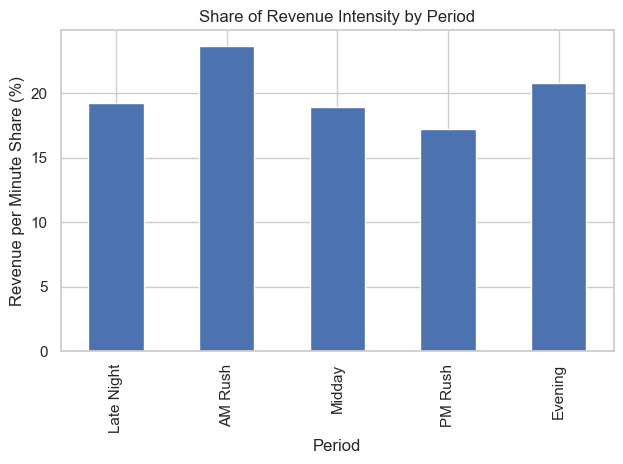

```python
summary["pct_share"].plot(kind="bar")
plt.ylabel("Revenue per Minute Share (%)")
plt.xlabel("Period")
plt.title("Share of Revenue Intensity by Period")
plt.tight_layout()
plt.show()
```

### Airport Trip Dynamics

Airport fee is present, hence, to isolate airport demand. Counting the number of airport trips per period.

```python
airport = regimes_df[regimes_df["airport_fee"] > 0]

airport.groupby("period", observed=False).size()
```

```
period
Late Night    1142
AM Rush       1337
Midday        2586
PM Rush       2259
Evening       2155
dtype: int64
```

Total airport fees by period (sum):

```python
airport = regimes_df[regimes_df["airport_fee"] > 0]

fee_totals = (
    airport
    .groupby("period", observed=False)["airport_fee"]
    .sum()
    .to_frame("total_airport_fees")
)

fee_totals
```

| period | total_airport_fees |
| --- | --- |
| Late Night | 1427.50 |
| AM Rush | 1671.25 |
| Midday | 3232.50 |
| PM Rush | 2823.75 |
| Evening | 2693.75 |

Further airport fee analysis:

```python
fee_summary = (
    airport
    .groupby("period", observed=False)["airport_fee"]
    .agg(
        trips="count",      # number of airport trips
        total="sum",        # total fee $
        mean="mean",        # avg fee per trip
        median="median"
    )
)

fee_summary["pct_share"] = 100 * fee_summary["total"] / fee_summary["total"].sum()

fee_summary
```

| period | trips | total | mean | median | pct_share |
| --- | --- | --- | --- | --- | --- |
| Late Night | 1142 | 1427.50 | 1.25 | 1.25 | 12.047684 |
| AM Rush | 1337 | 1671.25 | 1.25 | 1.25 | 14.104863 |
| Midday | 2586 | 3232.50 | 1.25 | 1.25 | 27.281359 |
| PM Rush | 2259 | 2823.75 | 1.25 | 1.25 | 23.831628 |
| Evening | 2155 | 2693.75 | 1.25 | 1.25 | 22.734466 |

### Further Visualization Examples

Visualizing of trips and trip percentage for the different regimes.

Trips Count Plot

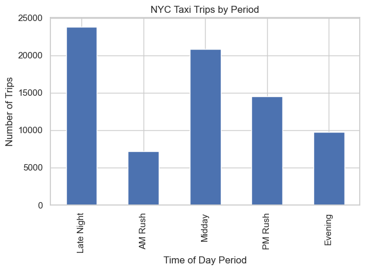

```python
import matplotlib.pyplot as plt

summary_trips = (
    regimes_df
    .groupby("period", observed=False)
    .size()
    .to_frame("trips")
)

ax = summary_trips["trips"].plot(kind="bar")

ax.set_xlabel("Time of Day Period")
ax.set_ylabel("Number of Trips")
ax.set_title("NYC Taxi Trips by Period")

plt.tight_layout()
plt.show()
```

Trips Percentage Plot:

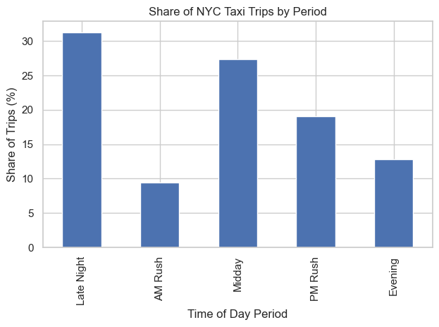

```python
summary_trip_percentage = summary_trips.copy()

summary_trip_percentage["trip_percentage"] = (
    100 * summary_trip_percentage["trips"] /
    summary_trip_percentage["trips"].sum()
)

ax = summary_trip_percentage["trip_percentage"].plot(kind="bar")

ax.set_xlabel("Time of Day Period")
ax.set_ylabel("Share of Trips (%)")
ax.set_title("Share of NYC Taxi Trips by Period")

plt.tight_layout()
plt.show()
```

Trips per hour visualisation:

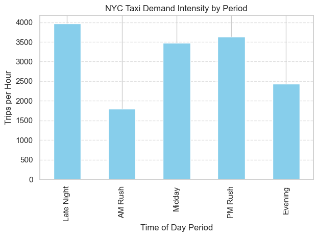

```python
import pandas as pd
import matplotlib.pyplot as plt
import numpy as np

# Step 1: Count trips per period
summary = regimes_df.groupby("period", observed=False).size().to_frame("trips")

# Step 2: Define period hours exactly matching period labels
period_hours = {
    "Late Night": 6,
    "AM Rush": 4,
    "Midday": 6,
    "PM Rush": 4,
    "Evening": 4
}

# Step 3: Compute trips per hour safely
# Convert index to string to avoid CategoricalIndex issues
summary["trips_per_hour"] = summary["trips"] / summary.index.astype(str).map(period_hours)

# Step 4: Order periods logically
order = ["Late Night","AM Rush","Midday","PM Rush","Evening"]
summary = summary.reindex(order)

# Step 5: Plot trips per hour
ax = summary["trips_per_hour"].plot(kind="bar", color="skyblue")

ax.set_xlabel("Time of Day Period")
ax.set_ylabel("Trips per Hour")
ax.set_title("NYC Taxi Demand Intensity by Period")
ax.grid(axis='y', linestyle='--', alpha=0.6)

plt.tight_layout()
plt.show()
```

Plots of other attributes of interest can also developed in similar fashion w.r.t. the regimes (including trips per hour...to be engineered).

```python
regimes_df.info()
```

```
<class 'pandas.core.frame.DataFrame'>
RangeIndex: 76115 entries, 0 to 76114
Data columns (total 26 columns):
 #   Column                 Non-Null Count  Dtype
---  ------                 --------------  -----
 0   vendorid               76115 non-null  int8
 1   tpep_pickup_datetime   76115 non-null  datetime64[ns]
 2   tpep_dropoff_datetime  76115 non-null  datetime64[ns]
 3   trip_minutes           76115 non-null  int32
 4   passenger_count        76115 non-null  int8
 5   trip_distance          76115 non-null  float64
 6   ratecodeid             76115 non-null  int8
 7   store_and_fwd_flag     76115 non-null  int64
 8   pulocationid           76115 non-null  int16
 9   dolocationid           76115 non-null  int16
```

[output cut: 18 more lines]

### Decision Making

Turn findings into decisions (real-world meaning)

Policy rules example:

1. If PM rush dominates → allocate more drivers
2. If late night has high $value per trip but low volume → surge pricing or incentives
3. If midday weak → promotions or pooled rides
4. If congestion high but revenue low → inefficiency zone

## Location Data Wrangling

By denormalising these spatial descriptors directly into the main dataset, the procedure eliminates repeated join operations and enables faster downstream analysis, including borough-level revenue aggregation, origin–destination flow matrices, service zone comparisons, and spatial demand modeling. The approach is memory-efficient, scalable to large taxi datasets, and includes integrity checks to detect unmatched locations. Overall, this transformation converts numeric location codes into interpretable geographic features, improving both analytical performance and interpretability of mobility and revenue analyses.

```python
regimes_df.info()
```

```
<class 'pandas.core.frame.DataFrame'>
RangeIndex: 76115 entries, 0 to 76114
Data columns (total 26 columns):
 #   Column                 Non-Null Count  Dtype
---  ------                 --------------  -----
 0   vendorid               76115 non-null  int8
 1   tpep_pickup_datetime   76115 non-null  datetime64[ns]
 2   tpep_dropoff_datetime  76115 non-null  datetime64[ns]
 3   trip_minutes           76115 non-null  int32
 4   passenger_count        76115 non-null  int8
 5   trip_distance          76115 non-null  float64
 6   ratecodeid             76115 non-null  int8
 7   store_and_fwd_flag     76115 non-null  int64
 8   pulocationid           76115 non-null  int16
 9   dolocationid           76115 non-null  int16
```

[output cut: 18 more lines]

Determining the number of unique cases in pulocationid and dolocationid.

```python
pu_unique = regimes_df['pulocationid'].unique()
len(pu_unique)
```

```
217
```

```python
do_unique = regimes_df['dolocationid'].unique()
len(do_unique)
```

```
256
```

Concerning 'pulocationID' and 'dolocationID'. There are 263 standard Location IDs (1–263) used by the NYC TLC, plus two special codes (264 and 265). Below is the full list of Location IDs categorized by Borough and Zone.

```python
regimes_df[['pulocationid', 'dolocationid']].describe()
```

|  | pulocationid | dolocationid |
| --- | --- | --- |
| count | 76115.000000 | 76115.000000 |
| mean | 158.969283 | 156.249189 |
| std | 65.792062 | 74.032200 |
| min | 1.000000 | 1.000000 |
| 25% | 114.000000 | 97.000000 |
| 50% | 151.000000 | 158.000000 |
| 75% | 230.000000 | 233.000000 |
| max | 265.000000 | 265.000000 |

Reviewing the location identification:

```python
zones_df.info()
```

```
<class 'pandas.core.frame.DataFrame'>
RangeIndex: 265 entries, 0 to 264
Data columns (total 4 columns):
 #   Column        Non-Null Count  Dtype
---  ------        --------------  -----
 0   LocationID    265 non-null    int64
 1   Borough       264 non-null    object
 2   Zone          264 non-null    object
 3   service_zone  263 non-null    object
dtypes: int64(1), object(3)
memory usage: 8.4+ KB
```

```python
import pandas as pd

# This removes the limit on displayed rows
pd.set_option('display.max_rows', None)

# Load the lookup table directly from the URL
url = "https://d37ci6vzurychx.cloudfront.net/misc/taxi_zone_lookup.csv"
zones_df = pd.read_csv(url)

# Display the first few rows
print(zones_df)
```

```
     LocationID        Borough                                           Zone  \
0             1            EWR                                 Newark Airport
1             2         Queens                                    Jamaica Bay
2             3          Bronx                        Allerton/Pelham Gardens
3             4      Manhattan                                  Alphabet City
4             5  Staten Island                                  Arden Heights
5             6  Staten Island                        Arrochar/Fort Wadsworth
6             7         Queens                                        Astoria
7             8         Queens                                   Astoria Park
8             9         Queens                                     Auburndale
9            10         Queens                                   Baisley Park
10           11       Brooklyn                                     Bath Beach
11           12      Manhattan                                   Battery Park
12           13      Manhattan                              Battery Park City
13           14       Brooklyn                                      Bay Ridge
```

[output cut: 518 more lines]

From the zones_df dataframe the goal is to use 'LocationID' as the identifier to assimilate the boroughs and zones (district or communities) into regimes_df. Yet, recall:

```python
len(pu_unique)
```

```
217
```

```python
len(do_unique)
```

```
256
```

**Pickup vs Dropoff uniqueness**

Pickup IDs: 217 unique values

Dropoff IDs: 256 unique values

Interpretation:

1. There are more dropoff locations than pickup locations.
2. This is consistent with NYC taxi trips — some zones (like airports or special areas) are more often destinations than origins.

There is need to perform two separate left merges. Since each row in regimes_df represents an independent trip, then, essentially "looking up" the location details twice: once for the pickup and once for the dropoff.

```python
import pandas as pd

# Merge for Pickup Location information
regimes_df = regimes_df.merge(
    zones_df[['LocationID', 'Borough', 'Zone']],
    left_on='pulocationid',
    right_on='LocationID',
    how='left'
).rename(columns={'Borough': 'pulocationid_borough', 'Zone': 'pulocationid_zone'}).drop(columns=['LocationID'])

# Merge for Dropoff Location information
regimes_df = regimes_df.merge(
    zones_df[['LocationID', 'Borough', 'Zone']],
    left_on='dolocationid',
    right_on='LocationID',
    how='left'
).rename(columns={'Borough': 'dolocationid_borough', 'Zone': 'dolocationid_zone'}).drop(columns=['LocationID'])

# Display the result
print(regimes_df[['pulocationid', 'pulocationid_borough', 'pulocationid_zone', 'dolocationid', 'dolocationid_borough', 'dolocationid_zone']].head())
```

```
   pulocationid pulocationid_borough  pulocationid_zone  dolocationid  \
0           161            Manhattan     Midtown Center           141
1            43            Manhattan       Central Park           237
2            48            Manhattan       Clinton East           238
3           138               Queens  LaGuardia Airport             7
4           107            Manhattan           Gramercy            79

  dolocationid_borough      dolocationid_zone
0            Manhattan        Lenox Hill West
1            Manhattan  Upper East Side South
2            Manhattan  Upper West Side North
3               Queens                Astoria
4            Manhattan           East Village
```

OBSERVATION & ANALYSIS OF DATA INTEGRITY MISHAPS

```python
regimes_df.isna().sum()
```

```
vendorid                    0
tpep_pickup_datetime        0
tpep_dropoff_datetime       0
trip_minutes                0
passenger_count             0
trip_distance               0
ratecodeid                  0
store_and_fwd_flag          0
pulocationid                0
dolocationid                0
payment_type                0
fare_amount                 0
extra                       0
mta_tax                     0
tip_amount                  0
tolls_amount                0
improvement_surcharge       0
total_amount                0
congestion_surcharge        0
airport_fee                 0
pickup_hour                 0
weekday                     0
period                      0
speed_mph                   0
tip_pct                     0
rev_per_min                 0
pulocationid_borough       23
pulocationid_zone        1169
dolocationid_borough      532
dolocationid_zone         588
dtype: int64
```

```python
# Filter for rows where the pickup zone name is missing
missing_pickup_zones = regimes_df[regimes_df['pulocationid_zone'].isna()]

# Count how many times each original ID appears in these missing records
na_id_counts = missing_pickup_zones['pulocationid'].value_counts()

print("Counts of original pulocationid for missing zones:")
print(na_id_counts)
```

```
Counts of original pulocationid for missing zones:
pulocationid
264    1169
Name: count, dtype: int64
```

That result confirms LocationID 264 is the sole culprit for your missing pickup data. Recall, there are two special codes (264 and 265), being unknown or outside NYC, respectively. The former as possibly technology mishaps.

```python
# Filter for rows where the dropoff zone name is missing
missing_dropoff_zones = regimes_df[regimes_df['dolocationid_zone'].isna()]

# Count how many times each original ID appears in these missing records
na_do_id_counts = missing_dropoff_zones['dolocationid'].value_counts()

print("Counts of original dolocationid for missing zones:")
print(na_do_id_counts)
```

```
Counts of original dolocationid for missing zones:
dolocationid
264    588
Name: count, dtype: int64
```

LocationID 264 is also the primary driver for missing dropoff information.

```python
# Filter for rows where the dropoff borough  name is missing
missing_dropoff_borough = regimes_df[regimes_df['pulocationid_borough'].isna()]

# Count how many times no dropoff borough name appears in these missing records
na_do_borough_counts = missing_dropoff_borough['pulocationid'].value_counts()

print("Counts of missing borough name:")
print(na_do_borough_counts)
```

```
Counts of missing borough name:
pulocationid
265    23
Name: count, dtype: int64
```

ID 265 corresponding to outside of NYC areas can't be associated with any borough or community (district).

```python
# Filter for rows where the pickup borough name is missing
missing_pickup_borough = regimes_df[regimes_df['pulocationid_borough'].isna()]

# Count how many times no pickup borough name appears in these missing records
na_pu_borough_counts = missing_pickup_borough['pulocationid'].value_counts()

print("Counts of missing borough name:")
print(na_pu_borough_counts)
```

```
Counts of missing borough name:
pulocationid
265    23
Name: count, dtype: int64
```

```python
regimes_df_clean = regimes_df.dropna().reset_index(drop=True)

regimes_df_clean.info()
```

```
<class 'pandas.core.frame.DataFrame'>
RangeIndex: 74293 entries, 0 to 74292
Data columns (total 30 columns):
 #   Column                 Non-Null Count  Dtype
---  ------                 --------------  -----
 0   vendorid               74293 non-null  int8
 1   tpep_pickup_datetime   74293 non-null  datetime64[ns]
 2   tpep_dropoff_datetime  74293 non-null  datetime64[ns]
 3   trip_minutes           74293 non-null  int32
 4   passenger_count        74293 non-null  int8
 5   trip_distance          74293 non-null  float64
 6   ratecodeid             74293 non-null  int8
 7   store_and_fwd_flag     74293 non-null  int64
 8   pulocationid           74293 non-null  int16
 9   dolocationid           74293 non-null  int16
```

[output cut: 22 more lines]

**The Math**

1. Original Rows: 76,115
2. Total "Dirty" Rows (Unique trips with at least one NaN): 1,822
3. Remaining Rows: 76,115 − 1,822 = 74,293

So, why 1,822 and not just the 1,192 or 1,120 we calculated earlier? It's because some trips had both a missing pickup AND a missing dropoff. dropna() removes the entire row if any column in that row contains a NaN.

### Pickup–Dropoff Flows (OD matrix by period)

```python
flows = (
    regimes_df_clean.groupby(["period", "pulocationid_borough", "dolocationid_borough"], observed=False)
      .size()
      .reset_index(name="trips")
)
```

```python
flows
```

|  | period | pulocationid_borough | dolocationid_borough | trips |
| --- | --- | --- | --- | --- |
| 0 | Late Night | Bronx | Bronx | 14 |
| 1 | Late Night | Bronx | Brooklyn | 1 |
| 2 | Late Night | Bronx | EWR | 0 |
| 3 | Late Night | Bronx | Manhattan | 5 |
| 4 | Late Night | Bronx | Queens | 2 |
| 5 | Late Night | Bronx | Staten Island | 0 |
| 6 | Late Night | Brooklyn | Bronx | 1 |
| 7 | Late Night | Brooklyn | Brooklyn | 212 |
| 8 | Late Night | Brooklyn | EWR | 0 |
| 9 | Late Night | Brooklyn | Manhattan | 168 |
| 10 | Late Night | Brooklyn | Queens | 30 |
| 11 | Late Night | Brooklyn | Staten Island | 1 |
| 12 | Late Night | EWR | Bronx | 0 |
| 13 | Late Night | EWR | Brooklyn | 0 |
| 14 | Late Night | EWR | EWR | 0 |
| 15 | Late Night | EWR | Manhattan | 0 |
| 16 | Late Night | EWR | Queens | 0 |
| 17 | Late Night | EWR | Staten Island | 0 |
| 18 | Late Night | Manhattan | Bronx | 229 |
| 19 | Late Night | Manhattan | Brooklyn | 1237 |
| 20 | Late Night | Manhattan | EWR | 68 |
| 21 | Late Night | Manhattan | Manhattan | 18698 |
| 22 | Late Night | Manhattan | Queens | 1328 |
| 23 | Late Night | Manhattan | Staten Island | 8 |
| 24 | Late Night | Queens | Bronx | 40 |
| 25 | Late Night | Queens | Brooklyn | 300 |
| 26 | Late Night | Queens | EWR | 1 |
| 27 | Late Night | Queens | Manhattan | 504 |
| 28 | Late Night | Queens | Queens | 511 |
| 29 | Late Night | Queens | Staten Island | 5 |

[output cut: 150 more lines]

One can extend prior to include 'pulocationid_zone' and 'dolocationid_zone' for more granularity in location.

### Cluster Periods Automatically (Data-Driven Regimes)

**The Elbow Method**

Calculate the Inertia (sum of squared distances to the nearest cluster center) for different values of k. You are looking for the "elbow"—the point where adding another cluster doesn't significantly reduce inertia.

**Silhouette Score**

If the "elbow" isn't clear, use the Silhouette Score. It measures how similar an hour is to its own cluster compared to other clusters. A score closer to 1 is better.

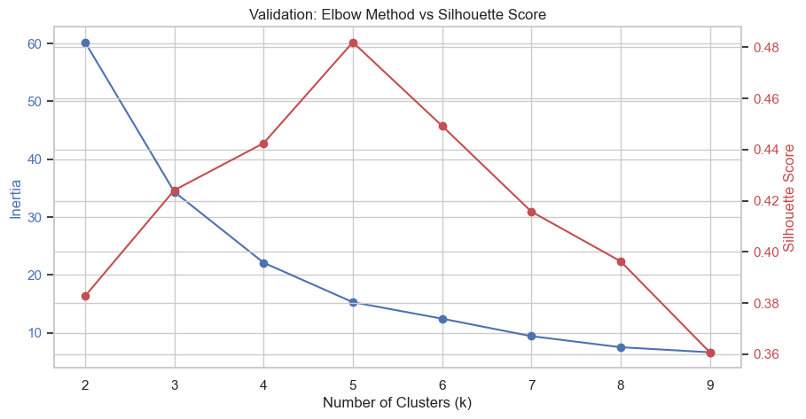

```
Silhouette Score for 5 clusters: 0.482
```

```python
import pandas as pd
import matplotlib.pyplot as plt
import seaborn as sns
import warnings
from sklearn.cluster import KMeans
from sklearn.preprocessing import StandardScaler
from sklearn.metrics import silhouette_score

# 1. Suppress the persistent Windows MKL warning
warnings.filterwarnings("ignore", message="KMeans is known to have a memory leak on Windows with MKL")

# 2. Aggregation: Grouping your 74,293 independent trips into 24 hourly profiles
hour_stats = (
    regimes_df_clean.groupby("pickup_hour", observed=False)
    .agg({
        "trip_minutes": "median",
        "speed_mph": "median",
        "total_amount": "median",
        "tip_pct": "mean",
    })
)

# 3. Scaling: Crucial for distance-based algorithms like KMeans
scaler = StandardScaler()
hour_stats_scaled = scaler.fit_transform(hour_stats)

# 4. ELBOW METHOD: Finding the "Optimal K"
inertia = []
K_range = range(2, 10)  # Start at 2 for silhouette compatibility
for k in K_range:
    model = KMeans(n_clusters=k, n_init=10, random_state=42)
    model.fit(hour_stats_scaled)
    inertia.append(model.inertia_)

# 5. SILHOUETTE SCORE: Measuring cluster quality
# A score closer to 1 means samples are far from neighboring clusters
s_scores = []
for k in K_range:
    model = KMeans(n_clusters=k, n_init=10, random_state=42)
    labels = model.fit_predict(hour_stats_scaled)
    s_scores.append(silhouette_score(hour_stats_scaled, labels))

# 6. VISUALIZATION: Validation Metrics
fig, ax1 = plt.subplots(figsize=(10, 5))

# Plot Inertia (Elbow)
ax1.plot(K_range, inertia, 'bo-', label='Inertia (Elbow)')
ax1.set_xlabel('Number of Clusters (k)')
ax1.set_ylabel('Inertia', color='b')
ax1.tick_params(axis='y', labelcolor='b')

# Plot Silhouette Score on same graph (secondary axis)
ax2 = ax1.twinx()
ax2.plot(K_range, s_scores, 'ro-', label='Silhouette Score')
ax2.set_ylabel('Silhouette Score', color='r')
ax2.tick_params(axis='y', labelcolor='r')

plt.title('Validation: Elbow Method vs Silhouette Score')
plt.show()

# 7. FINAL FIT: Based on your previous choice of k clusters
final_k = 5
kmeans = KMeans(n_clusters=final_k, n_init=10, random_state=42)
hour_stats["cluster"] = kmeans.fit_predict(hour_stats_scaled)

print(f"Silhouette Score for {final_k} clusters: {silhouette_score(hour_stats_scaled, hour_stats['cluster']):.3f}")
```

```
--- Hourly Cluster Profiles ---
         trip_minutes  speed_mph  total_amount   tip_pct
cluster
2           13.333333  12.070602     21.490000  0.177561
0           11.428571  13.681672     22.034286  0.195914
1            9.833333  15.660873     19.398333  0.172011
3           12.500000  16.557857     24.710000  0.183204
4           11.666667  20.379394     24.206667  0.149880
```

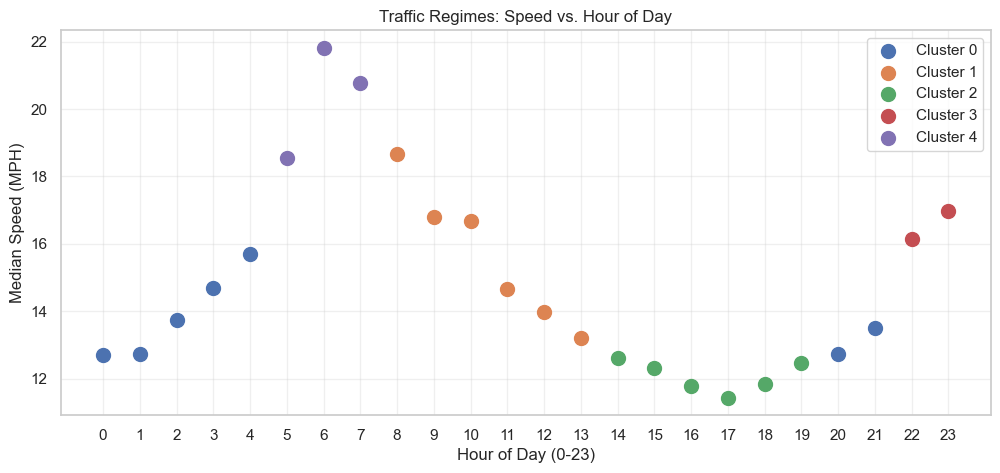

```python
import os
# Set this BEFORE importing sklearn to suppress the thread-leak warning
os.environ["OMP_NUM_THREADS"] = "1"

import warnings
warnings.filterwarnings("ignore", message="KMeans is known to have a memory leak on Windows with MKL")

import pandas as pd
import matplotlib.pyplot as plt
from sklearn.cluster import KMeans
from sklearn.preprocessing import StandardScaler

# 1. AGGREGATION
# We reduce the 74k trips into 24 hourly profiles
hour_stats = (
    regimes_df_clean.groupby("pickup_hour", observed=False)
    .agg({
        "trip_minutes": "median",
        "speed_mph": "median",
        "total_amount": "median",
        "tip_pct": "mean",
    })
)

# 2. SCALING
# KMeans is distance-based; we must scale so that 'speed' and 'money' are weighted equally
scaler = StandardScaler()
# We drop 'cluster' if it exists to ensure we only scale the original features
hour_stats_scaled = scaler.fit_transform(hour_stats.drop(columns=['cluster'], errors='ignore'))

# 3. MODELING
# We use KMeans (better for small datasets like 24 rows than MiniBatch)
# We set n_init=10 to ensure the algorithm finds the most stable centroids
kmeans = KMeans(n_clusters=5, n_init=10, random_state=42)
kmeans.fit(hour_stats_scaled)

# 4. ASSIGNMENT (The bridge to analysis)
# We map the resulting labels back to our hourly data
hour_stats["cluster"] = kmeans.labels_

# 5. ANALYSIS & PROFILING
# We calculate the mean of our metrics for each cluster to understand the "Regime"
cluster_profiles = hour_stats.groupby("cluster").mean().sort_values(by="speed_mph")

print("--- Hourly Cluster Profiles ---")
print(cluster_profiles)

# 6. VISUALIZATION OF REGIMES
plt.figure(figsize=(12, 5))
for cluster_id in range(5):
    cluster_data = hour_stats[hour_stats['cluster'] == cluster_id]
    plt.scatter(cluster_data.index, cluster_data['speed_mph'], label=f'Cluster {cluster_id}', s=100)

plt.title("Traffic Regimes: Speed vs. Hour of Day")
plt.xlabel("Hour of Day (0-23)")
plt.ylabel("Median Speed (MPH)")
plt.xticks(range(0, 24))
plt.legend()
plt.grid(alpha=0.3)
plt.show()
```

Insights:

1. finds natural regimes (not subjective bins)
2. Often reveals:

   ```
   Commute

   Business

   Nightlife

   Dead time
   ```

Even further, one can add other attributes or make various attribute substitutions. However, some of the integer types (int8, int16, int32) may be categorical or numeric in nature. Hence, identification is essential, and the K-prototypes algorithm with the ability to treat both numerical and categorical attributes is best.

## Geospatial Data Wrangling

Will now pursue augmenting the data with geospatial coordinates based on Ximena's geojson data file for TLC NYC Taxi Zones. Such task concerns development of geospatial clustering interests.

```python
!pip install kagglehub

import kagglehub

# Download latest version
path = kagglehub.dataset_download("mxruedag/tlc-nyc-taxi-zones")

print("Path to dataset files:", path)
```

```
Path to dataset files: C:\Users\verlene\.cache\kagglehub\datasets\mxruedag\tlc-nyc-taxi-zones\versions\2
```

What was downloaded?

```python
import os

for root, dirs, files in os.walk(path):
    for f in files:
        print(os.path.join(root, f))
```

```
C:\Users\verlene\.cache\kagglehub\datasets\mxruedag\tlc-nyc-taxi-zones\versions\2\NYC Taxi Zones.geojson
C:\Users\verlene\.cache\kagglehub\datasets\mxruedag\tlc-nyc-taxi-zones\versions\2\taxi_zones.csv
```

```python
import geopandas as gpd
import os

zones = gpd.read_file(os.path.join(path, "NYC Taxi Zones.geojson"))

# Project to NYC CRS (feet)
zones_proj = zones.to_crs(2263)

# Compute centroids safely
centroids = zones_proj.geometry.centroid

# Convert centroids back to lat/lon
centroids_ll = gpd.GeoSeries(centroids, crs=2263).to_crs(4326)

zones["lat"] = centroids_ll.y
zones["lon"] = centroids_ll.x

coords_lookup = zones[["location_id", "zone", "borough", "lat", "lon"]]

# Dropping possible duplicate rows
zones = zones.drop_duplicates(subset="location_id")

# A mild peek
zones.head()
```

|  | shape_area | objectid | shape_leng | location_id | zone | borough | geometry | lat | lon |
| --- | --- | --- | --- | --- | --- | --- | --- | --- | --- |
| 0 | 0.0007823067885 | 1 | 0.116357453189 | 1 | Newark Airport | EWR | MULTIPOLYGON (((-74.18445 40.695, -74.18449 40... | 40.691830 | -74.174002 |
| 1 | 0.00486634037837 | 2 | 0.43346966679 | 2 | Jamaica Bay | Queens | MULTIPOLYGON (((-73.82338 40.63899, -73.82277 ... | 40.616746 | -73.831300 |
| 2 | 0.000314414156821 | 3 | 0.0843411059012 | 3 | Allerton/Pelham Gardens | Bronx | MULTIPOLYGON (((-73.84793 40.87134, -73.84725 ... | 40.864474 | -73.847422 |
| 3 | 0.000111871946192 | 4 | 0.0435665270921 | 4 | Alphabet City | Manhattan | MULTIPOLYGON (((-73.97177 40.72582, -73.97179 ... | 40.723752 | -73.976968 |
| 4 | 0.000497957489363 | 5 | 0.0921464898574 | 5 | Arden Heights | Staten Island | MULTIPOLYGON (((-74.17422 40.56257, -74.17349 ... | 40.552659 | -74.188485 |

```python
zones.info()
```

```
<class 'geopandas.geodataframe.GeoDataFrame'>
Index: 260 entries, 0 to 262
Data columns (total 9 columns):
 #   Column       Non-Null Count  Dtype
---  ------       --------------  -----
 0   shape_area   260 non-null    object
 1   objectid     260 non-null    object
 2   shape_leng   260 non-null    object
 3   location_id  260 non-null    object
 4   zone         260 non-null    object
 5   borough      260 non-null    object
 6   geometry     260 non-null    geometry
 7   lat          260 non-null    float64
 8   lon          260 non-null    float64
dtypes: float64(2), geometry(1), object(6)
memory usage: 20.3+ KB
```

Merging pickup coordinates:

```python
# Ensuring matching dtype
coords_lookup = (
    zones[["location_id","zone","borough","lat","lon"]]
    .copy()
)

coords_lookup["location_id"] = coords_lookup["location_id"].astype(int)


regimes_df_clean = regimes_df_clean.merge(
    coords_lookup,
    left_on="pulocationid",
    right_on="location_id",
    how="left"
).rename(columns={
    "lat": "pu_lat",
    "lon": "pu_lon",
    "zone": "pu_zone",
    "borough": "pu_borough"
}).drop(columns=["location_id"])
```

```python
regimes_df_clean.info()
```

```
<class 'pandas.core.frame.DataFrame'>
RangeIndex: 74293 entries, 0 to 74292
Data columns (total 34 columns):
 #   Column                 Non-Null Count  Dtype
---  ------                 --------------  -----
 0   vendorid               74293 non-null  int8
 1   tpep_pickup_datetime   74293 non-null  datetime64[ns]
 2   tpep_dropoff_datetime  74293 non-null  datetime64[ns]
 3   trip_minutes           74293 non-null  int32
 4   passenger_count        74293 non-null  int8
 5   trip_distance          74293 non-null  float64
 6   ratecodeid             74293 non-null  int8
 7   store_and_fwd_flag     74293 non-null  int64
 8   pulocationid           74293 non-null  int16
 9   dolocationid           74293 non-null  int16
```

[output cut: 26 more lines]

Merging dropoff coordinates:

```python
# Deduplicate coords_lookup
coords_lookup = zones[["location_id","zone","borough","lat","lon"]].copy()
coords_lookup["location_id"] = coords_lookup["location_id"].astype(int)
coords_lookup = coords_lookup.drop_duplicates(subset=['location_id'], keep='first')

# Merge dropoff coordinates
regimes_df_clean = regimes_df_clean.merge(
    coords_lookup,
    left_on="dolocationid",
    right_on="location_id",
    how="left"
).rename(columns={
    "lat": "do_lat",
    "lon": "do_lon",
    "zone": "do_zone",
    "borough": "do_borough"
}).drop(columns=["location_id"])
```

```python
regimes_df_clean.info()
```

```
<class 'pandas.core.frame.DataFrame'>
RangeIndex: 74293 entries, 0 to 74292
Data columns (total 38 columns):
 #   Column                 Non-Null Count  Dtype
---  ------                 --------------  -----
 0   vendorid               74293 non-null  int8
 1   tpep_pickup_datetime   74293 non-null  datetime64[ns]
 2   tpep_dropoff_datetime  74293 non-null  datetime64[ns]
 3   trip_minutes           74293 non-null  int32
 4   passenger_count        74293 non-null  int8
 5   trip_distance          74293 non-null  float64
 6   ratecodeid             74293 non-null  int8
 7   store_and_fwd_flag     74293 non-null  int64
 8   pulocationid           74293 non-null  int16
 9   dolocationid           74293 non-null  int16
```

[output cut: 30 more lines]

```python
# Consistency sample check
consistency_df = regimes_df_clean[['pulocationid_borough', 'pu_borough', 'pulocationid_zone', 'pu_zone', 'dolocationid_borough', 'do_borough', 'dolocationid_zone', 'do_zone']]
consistency_df.head(100)
```

|  | pulocationid_borough | pu_borough | pulocationid_zone | pu_zone | dolocationid_borough | do_borough | dolocationid_zone | do_zone |
| --- | --- | --- | --- | --- | --- | --- | --- | --- |
| 0 | Manhattan | Manhattan | Midtown Center | Midtown Center | Manhattan | Manhattan | Lenox Hill West | Lenox Hill West |
| 1 | Manhattan | Manhattan | Central Park | Central Park | Manhattan | Manhattan | Upper East Side South | Upper East Side South |
| 2 | Manhattan | Manhattan | Clinton East | Clinton East | Manhattan | Manhattan | Upper West Side North | Upper West Side North |
| 3 | Queens | Queens | LaGuardia Airport | LaGuardia Airport | Queens | Queens | Astoria | Astoria |
| 4 | Manhattan | Manhattan | Gramercy | Gramercy | Manhattan | Manhattan | East Village | East Village |
| 5 | Manhattan | Manhattan | Midtown Center | Midtown Center | Manhattan | Manhattan | Kips Bay | Kips Bay |
| 6 | Manhattan | Manhattan | Upper West Side South | Upper West Side South | Manhattan | Manhattan | Lincoln Square West | Lincoln Square West |
| 7 | Manhattan | Manhattan | Lincoln Square East | Lincoln Square East | Bronx | Bronx | Riverdale/North Riverdale/Fieldston | Riverdale/North Riverdale/Fieldston |
| 8 | Manhattan | Manhattan | Midtown South | Midtown South | Manhattan | Manhattan | Upper East Side North | Upper East Side North |
| 9 | Manhattan | Manhattan | Lenox Hill West | Lenox Hill West | Manhattan | Manhattan | Gramercy | Gramercy |
| 10 | Manhattan | Manhattan | Union Sq | Union Sq | Manhattan | Manhattan | East Chelsea | East Chelsea |
| 11 | Manhattan | Manhattan | Midtown South | Midtown South | Manhattan | Manhattan | Lincoln Square West | Lincoln Square West |
| 12 | Queens | Queens | LaGuardia Airport | LaGuardia Airport | Brooklyn | Brooklyn | Brooklyn Heights | Brooklyn Heights |
| 13 | Brooklyn | Brooklyn | Brooklyn Heights | Brooklyn Heights | Brooklyn | Brooklyn | Crown Heights North | Crown Heights North |
| 14 | Manhattan | Manhattan | East Village | East Village | Manhattan | Manhattan | Penn Station/Madison Sq West | Penn Station/Madison Sq West |
| 15 | Manhattan | Manhattan | Flatiron | Flatiron | Manhattan | Manhattan | Clinton East | Clinton East |
| 16 | Manhattan | Manhattan | Greenwich Village North | Greenwich Village North | Brooklyn | Brooklyn | Williamsburg (North Side) | Williamsburg (North Side) |
| 17 | Manhattan | Manhattan | Upper East Side South | Upper East Side South | Manhattan | Manhattan | Upper West Side South | Upper West Side South |
| 18 | Manhattan | Manhattan | Lincoln Square West | Lincoln Square West | Manhattan | Manhattan | Sutton Place/Turtle Bay North | Sutton Place/Turtle Bay North |
| 19 | Manhattan | Manhattan | Kips Bay | Kips Bay | Manhattan | Manhattan | East Village | East Village |
| 20 | Queens | Queens | JFK Airport | JFK Airport | Manhattan | Manhattan | Hamilton Heights | Hamilton Heights |
| 21 | Manhattan | Manhattan | Midtown North | Midtown North | Manhattan | Manhattan | Midtown Center | Midtown Center |
| 22 | Manhattan | Manhattan | Midtown Center | Midtown Center | Manhattan | Manhattan | Midtown South | Midtown South |
| 23 | Manhattan | Manhattan | Midtown Center | Midtown Center | Manhattan | Manhattan | Financial District North | Financial District North |
| 24 | Manhattan | Manhattan | East Chelsea | East Chelsea | Manhattan | Manhattan | Midtown South | Midtown South |
| 25 | Manhattan | Manhattan | Midtown South | Midtown South | Manhattan | Manhattan | Two Bridges/Seward Park | Two Bridges/Seward Park |
| 26 | Manhattan | Manhattan | Central Park | Central Park | Manhattan | Manhattan | Yorkville East | Yorkville East |
| 27 | Manhattan | Manhattan | Yorkville West | Yorkville West | Manhattan | Manhattan | Yorkville East | Yorkville East |
| 28 | Manhattan | Manhattan | Yorkville West | Yorkville West | Manhattan | Manhattan | Sutton Place/Turtle Bay North | Sutton Place/Turtle Bay North |
| 29 | Manhattan | Manhattan | Murray Hill | Murray Hill | Manhattan | Manhattan | East Harlem South | East Harlem South |

[output cut: 70 more lines]

```python
zones.isna().sum()
```

```
shape_area     0
objectid       0
shape_leng     0
location_id    0
zone           0
borough        0
geometry       0
lat            0
lon            0
dtype: int64
```

```python
# For dropoff coordinates
na_dropoff_rows = regimes_df_clean[regimes_df_clean[['do_lat', 'do_lon']].isna().any(axis=1)]

# This removes the limit on displayed rows
pd.set_option('display.max_columns', None)

print(na_dropoff_rows)
```

```
       vendorid tpep_pickup_datetime tpep_dropoff_datetime  trip_minutes  \
1344          2  2023-01-01 00:45:57   2023-01-01 01:15:32            29
18584         1  2023-01-01 04:34:45   2023-01-01 04:54:41            19
18828         1  2023-01-01 04:29:00   2023-01-01 04:51:10            22
22875         2  2023-01-01 09:26:45   2023-01-01 09:35:51             9

       passenger_count  trip_distance  ratecodeid  store_and_fwd_flag  \
1344                 3          11.90           1                   0
18584                2           4.70           1                   0
18828                3          10.70           1                   0
22875                1           3.38           1                   0

       pulocationid  dolocationid  payment_type  fare_amount  extra  mta_tax  \
1344            263            57             2         51.3    1.0      0.5
18584             7            57             2         24.0    1.0      0.5
18828            79            57             2         41.5    3.5      0.5
22875           138            57             1         16.3    5.0      0.5

       tip_amount  tolls_amount  improvement_surcharge  total_amount  \
1344         0.00          6.55                    1.0         62.85
18584        0.00          0.00                    1.0         26.50
18828        0.00          0.00                    1.0         46.50
22875        4.56          0.00                    1.0         28.61

       congestion_surcharge  airport_fee  pickup_hour  weekday      period  \
1344                    2.5         0.00            0        6  Late Night
18584                   0.0         0.00            4        6  Late Night
18828                   2.5         0.00            4        6  Late Night
22875                   0.0         1.25            9        6     AM Rush

       speed_mph   tip_pct  rev_per_min pulocationid_borough  \
1344   24.620690  0.000000     2.167241            Manhattan
18584  14.842105  0.000000     1.394737               Queens
18828  29.181818  0.000000     2.113636            Manhattan
22875  22.533333  0.279755     3.178889               Queens

       pulocationid_zone dolocationid_borough dolocationid_zone  \
1344      Yorkville West               Queens            Corona
18584            Astoria               Queens            Corona
18828       East Village               Queens            Corona
22875  LaGuardia Airport               Queens            Corona

                 pu_zone pu_borough     pu_lat     pu_lon do_zone do_borough  \
1344      Yorkville West  Manhattan  40.778766 -73.951010     NaN        NaN
18584            Astoria     Queens  40.761493 -73.919694     NaN        NaN
18828       East Village  Manhattan  40.727620 -73.985937     NaN        NaN
22875  LaGuardia Airport     Queens  40.774376 -73.873628     NaN        NaN

       do_lat  do_lon
1344      NaN     NaN
18584     NaN     NaN
18828     NaN     NaN
22875     NaN     NaN
```

Well....a loss of 4 rows (**for whatever undiscovered reasons**) from instances of over 74,000 isn't bad.

## Geospatial Clustering of NYC Taxi Trips with Economic and Operational Features

Now, to pursue meaningful clusters of taxi trips in New York City that reflect not only geographic hotspots but also economic efficiency, operational characteristics, and demand intensity, providing insights for revenue management, service optimization, and urban mobility analysis.

There's preference for a concise, high-impact set of variables that captures microeconomics, operations, demand, and revenue, without overloading the model or diluting the clustering signal.

**Chosen Features for clustering**

Dimensions:

1. Geography: pu_lat, pu_lon. Spatial clusters are essential; where trips start is key.
2. Revenue / Micro-econ: rev_per_min. Normalizes revenue by trip duration, captures economic efficiency better than raw fare.
3. Demand: passenger_count. Captures trip volume per ride, indirectly reflecting demand intensity.
4. Operations: trip_minutes. Reflects operational cost/time, differentiates short vs long trips.
5. Optional Bonus: trip_distance. Adds info on trip scope; can help differentiate airport/long trips from local short trips.

```python
regimes_df_clean.info()
```

```
<class 'pandas.core.frame.DataFrame'>
RangeIndex: 74293 entries, 0 to 74292
Data columns (total 38 columns):
 #   Column                 Non-Null Count  Dtype
---  ------                 --------------  -----
 0   vendorid               74293 non-null  int8
 1   tpep_pickup_datetime   74293 non-null  datetime64[ns]
 2   tpep_dropoff_datetime  74293 non-null  datetime64[ns]
 3   trip_minutes           74293 non-null  int32
 4   passenger_count        74293 non-null  int8
 5   trip_distance          74293 non-null  float64
 6   ratecodeid             74293 non-null  int8
 7   store_and_fwd_flag     74293 non-null  int64
 8   pulocationid           74293 non-null  int16
 9   dolocationid           74293 non-null  int16
```

[output cut: 30 more lines]

Choice of clustering algorithm is HDBSCAN - Hierarchical Density-Based Spatial Clustering of Applications with Noise. Such can automatically find clusters at varying densities, robust to noise. Can be a bit slower than other conventional clustering algorithms. However, this algorithm handles density differences, outliers, with no need to predefine number of clusters. The pickup locations are likely dense in Manhattan, while sparse in outer boroughs → variable density. HDBSCAN automatically detects noise/outliers, which are common in taxi data (wrong coordinates, failed trips). Can handle mixed continuous features (after scaling) and produces cluster probabilities, which helps assess cluster confidence.

```python
!pip install hdbscan
```

```
Number of clusters found (excluding noise): 102
Number of noise points: 17832
```

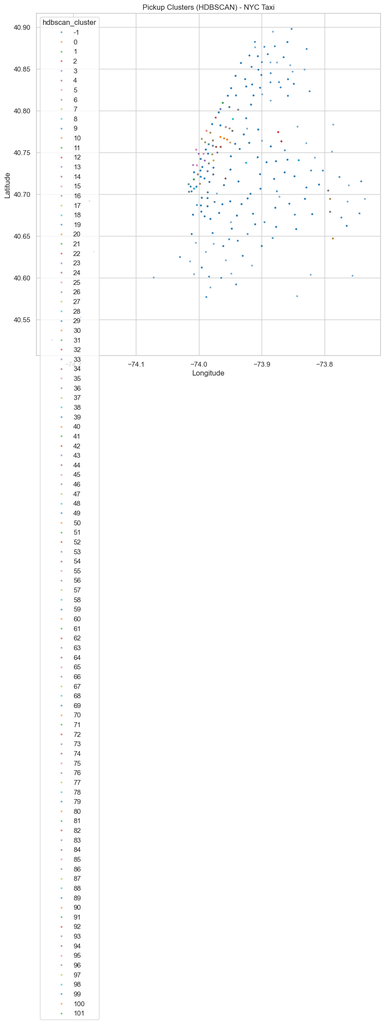

```
                    pu_lat     pu_lon  rev_per_min  passenger_count  \
hdbscan_cluster
-1               40.747992 -73.967561     2.508618         1.524563
 0               40.687909 -73.792759     3.492384         1.028571
 1               40.646985 -73.786530     3.006350         5.000000
 2               40.646985 -73.786530     2.693489         1.000000
 3               40.646985 -73.786530     2.632909         4.000000
 4               40.646985 -73.786530     2.752569         3.000000
 5               40.646985 -73.786530     2.405182         3.000000
 6               40.646985 -73.786530     2.632802         2.000000
 7               40.646985 -73.786530     2.708928         2.000000
 8               40.740674 -73.840865     4.388990         1.217391
 9               40.773467 -73.873197     3.062264         4.000000
 10              40.772459 -73.872718     2.991776         3.000000
 11              40.772838 -73.872941     2.971359         2.000000
```

[output cut: 196 more lines]

```python
# -----------------------------
# Importing libraries
# -----------------------------
import pandas as pd
import numpy as np
from sklearn.preprocessing import StandardScaler
import hdbscan
import matplotlib.pyplot as plt
import seaborn as sns

# -----------------------------
# Choice of features for clustering
# -----------------------------
features = [
    'pu_lat',        # Geography
    'pu_lon',        # Geography
    'rev_per_min',   # Revenue / Micro-econ
    'passenger_count',  # Demand
    'trip_minutes',     # Operations
    'trip_distance'     # Optional Bonus
]

df_cluster = regimes_df_clean[features].copy()

# -----------------------------
# Cleaning dataset (drop NaNs / invalid values)
# -----------------------------
df_cluster.dropna(inplace=True)
df_cluster = df_cluster[
    (df_cluster['rev_per_min'] > 0) &
    (df_cluster['trip_minutes'] > 0) &
    (df_cluster['trip_distance'] > 0)
]

# Reset index for convenience
df_cluster.reset_index(drop=True, inplace=True)

# -----------------------------
# Scaling numeric features
# -----------------------------
scaler = StandardScaler()
X_scaled = scaler.fit_transform(df_cluster)
X_scaled[:, 0:2] *= 2  # double the weight of latitude/longitude


# -----------------------------
# HDBSCAN clustering
# -----------------------------
# Choosing min_cluster_size based on expected cluster size
hdb = hdbscan.HDBSCAN(
    min_cluster_size = 20,     # tweak depending on density you expect
    metric='euclidean',
    cluster_selection_method='eom',  # extracts stable clusters
    prediction_data=True       # allows later prediction of new points if needed
)
df_cluster['hdbscan_cluster'] = hdb.fit_predict(X_scaled)

# -1 indicates noise points (outliers)
print(f"Number of clusters found (excluding noise): {len(set(df_cluster['hdbscan_cluster'])) - (1 if -1 in df_cluster['hdbscan_cluster'].values else 0)}")
print(f"Number of noise points: {(df_cluster['hdbscan_cluster'] == -1).sum()}")

# -----------------------------
# Visualizing clusters geographically
# -----------------------------
plt.figure(figsize=(10, 10))
sns.scatterplot(
    x='pu_lon',
    y='pu_lat',
    hue='hdbscan_cluster',
    palette='tab10',
    data=df_cluster,
    legend='full',
    s=10,
    alpha=0.6
)
plt.xlabel('Longitude')
plt.ylabel('Latitude')
plt.title('Pickup Clusters (HDBSCAN) - NYC Taxi')
plt.show()

# -----------------------------
# Summary statistics per cluster
# -----------------------------
cluster_summary = df_cluster.groupby('hdbscan_cluster')[features].mean()
print(cluster_summary)
```

1. Many points are labeled -1 (light blue):

   ```
   In HDBSCAN, -1 indicates noise/outliers.

   This often happens when:

         The data is sparse relative to min_cluster_size.

         There exists wide variation in density (e.g., NYC downtown vs outer boroughs).
   ```

   ```
   Most clusters are small and localized, possibly reflecting Midtown/airport zones or other dense pickup areas.

   However, they appear tiny relative to the full NYC area, which makes it hard to interpret meaningful “hotspots” at a glance.
   ```

3. Clusters are geographically tight:

   ```
   HDBSCAN is doing what it’s designed to do: detecting densely packed points and ignoring everything else as noise.

HDBSCAN is sensitive to density:

[output not shown]

lusters are very small relative to NYC geography:

```
This means the algorithm is capturing micro-hotspots, but not giving a full city-wide segmentation.
```

Noise points are not necessarily bad trips:

```
Many of the -1 points could be:

   Trips from outer boroughs

   Long-distance trips

   Trips at unusual hours
```

Using Folium maps with heatmaps or cluster markers — makes it easier to interpret pickup zones than a static scatter plot.

olium is excellent for geospatial data, and it’s far more interpretable than a scatter plot. We can do two types of maps:

```python
!pip install folium
```

```python
# -----------------------------
# Importing libraries
# -----------------------------
import folium
from folium.plugins import HeatMap, MarkerCluster
import pandas as pd

# To make use df_cluster from hdbscan earlier
# 'pu_lat', 'pu_lon', 'hdbscan_cluster'

# -----------------------------
# Base map of NYC
# -----------------------------
nyc_map = folium.Map(
    location=[40.75, -73.98],  # Manhattan center
    zoom_start=11,
    tiles='cartodbpositron'
)

# -----------------------------
# Adding HeatMap of pickups
# -----------------------------
heat_data = df_cluster[['pu_lat', 'pu_lon']].values.tolist()
HeatMap(heat_data, radius=8, blur=15).add_to(nyc_map)

# Display map
nyc_map
```

Make this Notebook Trusted to load map: File -> Trust Notebook

[interactive chart not shown]

## Supervised Models for Revenue Prediction

### The Analytical Structure (which MAY introduce cognitive bias)

Aside from the role of travel mechanics, revenue is driven by fare rules + demand dynamics + operational factors. A decent conceptual model:

$$\text{Revenue = Fare formula + policy surcharges + behavioural components (tips) + market effects}$$

The acquired dataframe 'regimes_df_clean' generally has (almost) everything needed to build a structurally complete revenue model. There is now interest in mapping variables into economic drivers of taxi revenue, not just raw columns.

To now organise the dataframe columns into causal buckets (fare mechanics → tips → spatial → demand → utilization), and clearly exhibit what each captures.

#### Metered Fare Mechanics (Deterministic Pricing Rules)

1. Distance component

   ```
   trip_distance
   ```

2. Time component

   ```
   trip_minutes

   speed_mph (derived efficiency diagnostic)
   ```

3. Fare schedule / policy

   ```
   fare_amount (already computed by TLC meter)

   extra (night/peak charges)

   mta_tax

   improvement_surcharge

   congestion_surcharge

   tolls_amount

   airport_fee

   ratecodeid (airport flat fare, special rates)
   ```

4. Total charged fare

   ```
   total_amount (fare + tips + surcharges)
   ```

#### Tip Behaviour (Behavioural Revenue Component being the largest stochastic part)

1. Direct

   ```
   tip_amount

   tip_pct
   ```

Strong predictors of tipping:

```
payment_type (card → tips; cash → often zero)

fare_amount (tips proportional to fare)

airport_fee (airport riders tip more)

trip_minutes / trip_distance

period, pickup_hour, weekday

borough/zone (business districts tip more)
```

#### Temporal Demand Effects (Periodicity / Congestion / Supply-Demand)

Captures when revenue is higher.

```
pickup_hour

weekday

period

trip_minutes (captures traffic indirectly)

speed_mph (good congestion proxy)
```

Optional improvements (**but too much of a hassle at tis time**):

```
weather

holidays

events
```

The time variables already span daily + weekly cycles well.

#### Spatial Economics (explains a lot of fare variance)

1. Pickup side

   ```
   pulocationid

   pulocationid_borough

   pulocationid_zone
   ```

2. Dropoff side

   ```
   dolocationid

   dolocationid_borough

   dolocationid_zone
   ```

These capture:

```
Manhattan short/high-frequency trips

airport long trips

outer borough low tip behavior

CBD business tipping
```

Spatial fixed effects are often stronger than congestion.

#### Trip Intensity / Utilisation (driver revenue per time)

This determines earnings rate, not just trip revenue.

Already present:

```
rev_per_min - excellent target for driver economics

trip_minutes
```

If modeling driver income:

$$\text{Revenue Rate} = \frac{\text{Total Amount}}{\text{Trip Minutea}}$$

#### Service / Operational Factors

Minor but useful:

```
vendorid (company effects)

store_and_fwd_flag (offline recording anomalies)

passenger_count (group size may influence tips)
```

#### Mapping Dataframe to a Structural Model

**Caveat**: not to predict a variable from its algebraic components, because

$$total\,amount\,=\,fare\,amount + tip\,amount + surcharges + tolls$$

just **“rediscovers addition” (data leakage)**.

Of consequence, to design two proper targets (depending on business goal):

1. Trip revenue (behavioural uncertainty only)

   ```
   tip_amount
   ```

2. Driver productivity

   ```
   rev_per_min: strongest practical KPI

        This avoids fare arithmetic leakage and captures:

            demand

            congestion

            tipping

            spatial economics
   ```

Full revenue (without leakage)

```
Exclude fare components from predictors
```

**Model Strategy:**

```
Structural decomposition (best practice)

    Fare → deterministic (no ML needed)

    Tip → ML

    Revenue rate → ML
```

Target: rev_per_min

```
Features:
    Time {pickup_hour,  weekday, period)
    Trip mechanics {trip_distance, trip_minutes, speed_mph, passenger_count}
    Market / behaviour {payment_type, ratecodeid, airport_fee}
    Spatial {pulocationid_borough, dolocationid_borough}
```

Since there are various categorical features considered, regression models are not considered.

#### Tree Ensemble (nonlinear + interactions)

Trees work better for:

1. zone effects
2. tipping behaviour
3. nonlinear congestion
4. threshold effects (airport vs non-airport)

```python
check_cat_cols = [
    "period",
    "payment_type",
    "ratecodeid",
    "pulocationid_borough",
    "dolocationid_borough"
]

regimes_df_clean[check_cat_cols].head(10)
```

|  | period | payment_type | ratecodeid | pulocationid_borough | dolocationid_borough |
| --- | --- | --- | --- | --- | --- |
| 0 | Late Night | 2 | 1 | Manhattan | Manhattan |
| 1 | Late Night | 1 | 1 | Manhattan | Manhattan |
| 2 | Late Night | 1 | 1 | Manhattan | Manhattan |
| 3 | Late Night | 1 | 1 | Queens | Queens |
| 4 | Late Night | 1 | 1 | Manhattan | Manhattan |
| 5 | Late Night | 1 | 1 | Manhattan | Manhattan |
| 6 | Late Night | 1 | 1 | Manhattan | Manhattan |
| 7 | Late Night | 1 | 1 | Manhattan | Bronx |
| 8 | Late Night | 1 | 1 | Manhattan | Manhattan |
| 9 | Late Night | 2 | 1 | Manhattan | Manhattan |

```python
check_num_cols = [
    "trip_distance",
    "trip_minutes",
    "speed_mph",
    "passenger_count",
    "pickup_hour",
    "weekday",
    "airport_fee"
]
regimes_df_clean[check_num_cols].head(10)
```

|  | trip_distance | trip_minutes | speed_mph | passenger_count | pickup_hour | weekday | airport_fee |
| --- | --- | --- | --- | --- | --- | --- | --- |
| 0 | 0.97 | 8 | 7.275000 | 1 | 0 | 6 | 0.00 |
| 1 | 1.10 | 6 | 11.000000 | 1 | 0 | 6 | 0.00 |
| 2 | 2.51 | 12 | 12.550000 | 1 | 0 | 6 | 0.00 |
| 3 | 1.90 | 9 | 12.666667 | 0 | 0 | 6 | 1.25 |
| 4 | 1.43 | 10 | 8.580000 | 1 | 0 | 6 | 0.00 |
| 5 | 1.84 | 12 | 9.200000 | 1 | 0 | 6 | 0.00 |
| 6 | 1.66 | 10 | 9.960000 | 1 | 0 | 6 | 0.00 |
| 7 | 11.70 | 22 | 31.909091 | 1 | 0 | 6 | 0.00 |
| 8 | 2.95 | 14 | 12.642857 | 1 | 0 | 6 | 0.00 |
| 9 | 3.01 | 10 | 18.060000 | 1 | 0 | 6 | 0.00 |

```python
!pip install lightgbm
```

[output not shown]

```python
import pandas as pd
import numpy as np
from sklearn.model_selection import train_test_split
from sklearn.compose import ColumnTransformer
from sklearn.preprocessing import OrdinalEncoder, StandardScaler
from sklearn.pipeline import Pipeline
from sklearn.ensemble import RandomForestRegressor
from sklearn.metrics import r2_score, mean_absolute_error

# 1. Setup Data
df = regimes_df_clean.copy()
target = "rev_per_min"

num_cols = ["trip_distance", "trip_minutes", "speed_mph", "passenger_count", "pickup_hour", "weekday", "airport_fee"]
cat_cols = ["period", "payment_type", "ratecodeid", "pulocationid_borough", "dolocationid_borough"]

X = df[num_cols + cat_cols]
y = df[target]

# Split data
X_train, X_test, y_train, y_test = train_test_split(X, y, test_size=0.2, random_state=42)

# 2. Define Preprocessing
# We use OrdinalEncoder to keep data in a single column per feature.
# handle_unknown='use_encoded_value' ensures new categories don't crash the model.
preprocess = ColumnTransformer([
    ("num", StandardScaler(), num_cols),
    ("cat", OrdinalEncoder(handle_unknown="use_encoded_value", unknown_value=-1), cat_cols)
])

# 3. Create the Pipeline
rf = Pipeline([
    ("prep", preprocess),
    ("rf", RandomForestRegressor(
        n_estimators=300,
        max_depth=None,
        min_samples_leaf=5,
        n_jobs=-1,
        random_state=42
    ))
])

# 4. Fit the Model
rf.fit(X_train, y_train)

# 5. Evaluate
pred = rf.predict(X_test)
print(f"R2: {r2_score(y_test, pred)}")
print(f"MAE: {mean_absolute_error(y_test, pred)}")

# --- 6. GENERATE THE "HUMAN INTERPRETABLE" LEGEND ---
print("\n" + "="*30)
print("CATEGORY ENCODING LEGEND")
print("="*30)

# Extract the encoder from the pipeline
encoder = rf.named_steps['prep'].named_transformers_['cat']

for i, col_name in enumerate(cat_cols):
    print(f"\nFeature: {col_name}")
    # Map the index to the category name
    for val, label in enumerate(encoder.categories_[i]):
        print(f"  {val} -> {label}")
```

```
R2: 0.9053822191413625
MAE: 0.15378215530685257

==============================
CATEGORY ENCODING LEGEND
==============================

Feature: period
  0 -> AM Rush
  1 -> Evening
  2 -> Late Night
  3 -> Midday
  4 -> PM Rush

Feature: payment_type
  0 -> 1
  1 -> 2
  2 -> 3
  3 -> 4

Feature: ratecodeid
  0 -> 1
  1 -> 2
  2 -> 3
  3 -> 4
  4 -> 5
  5 -> 99

Feature: pulocationid_borough
  0 -> Bronx
  1 -> Brooklyn
  2 -> EWR
  3 -> Manhattan
  4 -> Queens
  5 -> Staten Island

Feature: dolocationid_borough
  0 -> Bronx
  1 -> Brooklyn
  2 -> EWR
  3 -> Manhattan
  4 -> Queens
  5 -> Staten Island
```

Random Forest development:

```python
# Prepping the random forest model
rf = Pipeline([
    ("prep", preprocess),
    ("rf", RandomForestRegressor(
        n_estimators=300,
        max_depth=None,
        min_samples_leaf=5,
        n_jobs=-1,
        random_state=42
    ))
])

# Fitting the model Model
rf.fit(X_train, y_train)
pred = rf.predict(X_test)

# Model evaluation
print("R2:", r2_score(y_test, pred))
print("MAE:", mean_absolute_error(y_test, pred))
```

```
R2: 0.9053822191413625
MAE: 0.15378215530685257
```

For a Mean Absolute Error (MAE) just beneath 0.154 indicates that, on average, the predictions are off by only about 0.15 units.

To now perform "unit testing" or individual unique test cases or scenarios with the model. Since the Random Forest is wrapped in a Pipeline, there must certainty that the individual test cases are passed in as a DataFrame with the exact same column names used during training. Creating a dictionary where each key is a scenario name and the value is a DataFrame row:

```python
X.head(20)
```

|  | trip_distance | trip_minutes | speed_mph | passenger_count | pickup_hour | weekday | airport_fee | period | payment_type | ratecodeid | pulocationid_borough | dolocationid_borough |
| --- | --- | --- | --- | --- | --- | --- | --- | --- | --- | --- | --- | --- |
| 0 | 0.97 | 8 | 7.275000 | 1 | 0 | 6 | 0.00 | Late Night | 2 | 1 | Manhattan | Manhattan |
| 1 | 1.10 | 6 | 11.000000 | 1 | 0 | 6 | 0.00 | Late Night | 1 | 1 | Manhattan | Manhattan |
| 2 | 2.51 | 12 | 12.550000 | 1 | 0 | 6 | 0.00 | Late Night | 1 | 1 | Manhattan | Manhattan |
| 3 | 1.90 | 9 | 12.666667 | 0 | 0 | 6 | 1.25 | Late Night | 1 | 1 | Queens | Queens |
| 4 | 1.43 | 10 | 8.580000 | 1 | 0 | 6 | 0.00 | Late Night | 1 | 1 | Manhattan | Manhattan |
| 5 | 1.84 | 12 | 9.200000 | 1 | 0 | 6 | 0.00 | Late Night | 1 | 1 | Manhattan | Manhattan |
| 6 | 1.66 | 10 | 9.960000 | 1 | 0 | 6 | 0.00 | Late Night | 1 | 1 | Manhattan | Manhattan |
| 7 | 11.70 | 22 | 31.909091 | 1 | 0 | 6 | 0.00 | Late Night | 1 | 1 | Manhattan | Bronx |
| 8 | 2.95 | 14 | 12.642857 | 1 | 0 | 6 | 0.00 | Late Night | 1 | 1 | Manhattan | Manhattan |
| 9 | 3.01 | 10 | 18.060000 | 1 | 0 | 6 | 0.00 | Late Night | 2 | 1 | Manhattan | Manhattan |
| 10 | 1.80 | 8 | 13.500000 | 1 | 0 | 6 | 0.00 | Late Night | 1 | 1 | Manhattan | Manhattan |
| 11 | 3.23 | 29 | 6.682759 | 1 | 0 | 6 | 0.00 | Late Night | 1 | 1 | Manhattan | Manhattan |
| 12 | 11.43 | 19 | 36.094737 | 2 | 0 | 6 | 1.25 | Late Night | 1 | 1 | Queens | Brooklyn |
| 13 | 2.95 | 15 | 11.800000 | 1 | 0 | 6 | 0.00 | Late Night | 1 | 1 | Brooklyn | Brooklyn |
| 14 | 1.52 | 9 | 10.133333 | 1 | 0 | 6 | 0.00 | Late Night | 1 | 1 | Manhattan | Manhattan |
| 15 | 2.23 | 22 | 6.081818 | 1 | 0 | 6 | 0.00 | Late Night | 1 | 1 | Manhattan | Manhattan |
| 16 | 4.50 | 14 | 19.285714 | 1 | 0 | 6 | 0.00 | Late Night | 1 | 1 | Manhattan | Brooklyn |
| 17 | 1.20 | 6 | 12.000000 | 3 | 0 | 6 | 0.00 | Late Night | 2 | 1 | Manhattan | Manhattan |
| 18 | 2.50 | 14 | 10.714286 | 2 | 0 | 6 | 0.00 | Late Night | 2 | 1 | Manhattan | Manhattan |
| 19 | 1.40 | 6 | 14.000000 | 1 | 0 | 6 | 0.00 | Late Night | 1 | 1 | Manhattan | Manhattan |

Viewing the encoded data (matrix):

```python
# Access the 'prep' step and get the feature names
feature_names = rf.named_steps['prep'].get_feature_names_out()

# Display the first 20 feature names
print(feature_names[:20])


# Transform the data using only the 'prep' step
X_test_transformed = rf.named_steps['prep'].transform(X_test)

# Convert to a DataFrame for better readability
import pandas as pd
encoded_df = pd.DataFrame(
    X_test_transformed,
    columns=feature_names,
    index=X_test.index
)

encoded_df.head(20)
```

```
['num__trip_distance' 'num__trip_minutes' 'num__speed_mph'
 'num__passenger_count' 'num__pickup_hour' 'num__weekday'
 'num__airport_fee' 'cat__period' 'cat__payment_type' 'cat__ratecodeid'
 'cat__pulocationid_borough' 'cat__dolocationid_borough']
```

|  | num__trip_distance | num__trip_minutes | num__speed_mph | num__passenger_count | num__pickup_hour | num__weekday | num__airport_fee | cat__period | cat__payment_type | cat__ratecodeid | cat__pulocationid_borough | cat__dolocationid_borough |
| --- | --- | --- | --- | --- | --- | --- | --- | --- | --- | --- | --- | --- |
| 51353 | -0.731232 | -0.315465 | -1.384001 | 0.447013 | 0.857401 | 0.297202 | -0.369154 | 4.0 | 0.0 | 0.0 | 3.0 | 3.0 |
| 65558 | 1.013639 | 1.174624 | 0.463945 | 0.447013 | 1.548973 | 0.297202 | 2.708893 | 1.0 | 0.0 | 0.0 | 4.0 | 3.0 |
| 37742 | 2.589839 | 1.612886 | 1.730844 | -0.535814 | 0.442458 | 0.297202 | 2.708893 | 3.0 | 0.0 | 1.0 | 4.0 | 3.0 |
| 4609 | -0.558684 | -0.315465 | -0.855289 | 2.412666 | -1.493944 | 0.297202 | -0.369154 | 2.0 | 0.0 | 0.0 | 3.0 | 3.0 |
| 72850 | -0.304708 | -0.315465 | -0.077073 | -0.535814 | -0.525743 | -3.367252 | -0.369154 | 0.0 | 0.0 | 0.0 | 3.0 | 3.0 |
| 21161 | -0.750620 | -1.016684 | -0.492913 | -0.535814 | -0.525743 | 0.297202 | -0.369154 | 0.0 | 0.0 | 0.0 | 3.0 | 3.0 |
| 48749 | -0.700212 | 0.473406 | -1.518852 | -0.535814 | 0.857401 | 0.297202 | -0.369154 | 4.0 | 0.0 | 0.0 | 3.0 | 3.0 |
| 67850 | -0.702151 | -1.016684 | 0.051640 | -0.535814 | 1.687287 | 0.297202 | -0.369154 | 1.0 | 0.0 | 0.0 | 3.0 | 3.0 |
| 67572 | -0.269811 | -0.227813 | -0.122617 | -0.535814 | 1.687287 | 0.297202 | -0.369154 | 1.0 | 0.0 | 0.0 | 3.0 | 3.0 |
| 9731 | 0.371914 | 1.174624 | -0.308543 | -0.535814 | -1.217315 | 0.297202 | -0.369154 | 2.0 | 0.0 | 0.0 | 3.0 | 3.0 |
| 12047 | -0.353177 | -0.315465 | -0.225587 | 0.447013 | -1.217315 | 0.297202 | -0.369154 | 2.0 | 1.0 | 0.0 | 3.0 | 4.0 |
| 13314 | -0.729294 | -1.104336 | 0.519956 | -0.535814 | -1.217315 | 0.297202 | -0.369154 | 2.0 | 0.0 | 0.0 | 3.0 | 3.0 |
| 8781 | -0.692457 | -0.929031 | -0.329547 | -0.535814 | -1.355629 | 0.297202 | -0.369154 | 2.0 | 1.0 | 0.0 | 3.0 | 3.0 |
| 26087 | 1.056291 | 0.473406 | 1.441340 | 0.447013 | -0.110800 | 0.297202 | -0.369154 | 3.0 | 0.0 | 0.0 | 3.0 | 4.0 |
| 10417 | 0.528952 | 1.086972 | -0.057271 | -0.535814 | -1.217315 | 0.297202 | -0.369154 | 2.0 | 0.0 | 0.0 | 3.0 | 3.0 |
| 34279 | -0.516032 | -0.052508 | -0.955006 | -0.535814 | 0.304143 | 0.297202 | -0.369154 | 3.0 | 0.0 | 0.0 | 3.0 | 3.0 |
| 47369 | 2.273824 | 2.314104 | 0.782138 | -0.535814 | 0.719086 | 0.297202 | 2.708893 | 4.0 | 0.0 | 0.0 | 4.0 | 1.0 |
| 58300 | 0.858539 | 0.385753 | 1.261122 | -0.535814 | 1.134029 | 0.297202 | 2.708893 | 4.0 | 1.0 | 0.0 | 4.0 | 1.0 |
| 64049 | -0.525725 | -0.490770 | -0.521956 | -0.535814 | 1.548973 | 0.297202 | -0.369154 | 1.0 | 1.0 | 0.0 | 3.0 | 3.0 |
| 37057 | -0.576133 | -0.403117 | -0.819645 | -0.535814 | 0.442458 | 0.297202 | -0.369154 | 3.0 | 0.0 | 0.0 | 3.0 | 3.0 |

```python
# Define specific (regime type) scenarios to test
scenarios = {
    "Short City Hop": {
        'trip_distance': 1.2, 'trip_minutes': 8.0, 'speed_mph': 9.0,
        'passenger_count': 1, 'pickup_hour': 14, 'weekday': 2, 'airport_fee': 0,
        'dolocationid_borough': 1,
        'pulocationid_borough': 2,
        'payment_type': 3,
        'period': 4,
        'ratecodeid': 5
    },
    "Airport Run (Rush Hour)": {
        'trip_distance': 18.5, 'trip_minutes': 55.0, 'speed_mph': 20.0,
        'passenger_count': 2, 'pickup_hour': 17, 'weekday': 4, 'airport_fee': 1.25,
        'dolocationid_borough': 3,
        'pulocationid_borough': 1,
        'payment_type': 4,
        'period': 3,
        'ratecodeid': 2 # Often the code for JFK
    }
}

# The general scenario: determining the anticipated revenue per minute for trip distance of A miles, with a duration of B minutes,
        # traversing with an average speed of C miles per hour, having a passenger occupancy of D individuals, starting at time E (timestamp), during weekday operations,
        # whose (final) destination is the airport (airport fee charge), coming from borough F, going to borough G, with payment method I, during part of the day J, etc.

# 1. Ensure the types are correct to avoid the previous error
for col in cat_cols:
    test_cases[col] = test_cases[col].astype(str)

# 2. Get the predictions
test_cases['prediction'] = rf.predict(test_cases)

# 3. Transpose the dataframe for a clean, vertical layout
printable_results = test_cases.T

# 4. Display
print("=== TRIP SCENARIO COMPARISON ===")
print(printable_results)
```

```
=== TRIP SCENARIO COMPARISON ===
                     Short City Hop Airport Run (Rush Hour)
trip_distance                   1.2                    18.5
trip_minutes                    8.0                    55.0
speed_mph                       9.0                    20.0
passenger_count                   1                       2
pickup_hour                      14                      17
weekday                           2                       4
airport_fee                     0.0                    1.25
dolocationid_borough              1                       3
pulocationid_borough              2                       1
payment_type                      3                       4
period                            4                       3
ratecodeid                        5                       2
prediction                 2.002632                1.777517
```

### Feature Importance and Feature Selection

To exhibit which factors actually drive revenue, to use two different approaches:

1. Model-Based Importance (Random Forest's internal view)

   ```
   This shows which features the model relied on most to make its decisions.
   ```

2. Statistical Selection (SelectKBest)

   ```
   This is a more "selective" approach. It uses statistical tests (like f_regression) to pick the top K features before the model even sees them. This is great for simplifying your model for an audience.
   ```

[figure not shown]

```python
import matplotlib.pyplot as plt
import seaborn as sns

# 1. Extract feature names and importances
# 'prep' is your ColumnTransformer; 'rf' is the model
feature_names = rf.named_steps['prep'].get_feature_names_out()
importances = rf.named_steps['rf'].feature_importances_

# 2. Create a DataFrame for plotting
fi_df = pd.DataFrame({'Feature': feature_names, 'Importance': importances})
fi_df = fi_df.sort_values(by='Importance', ascending=False)

# 3. Plotting
# Create the plot without the warning
plt.figure(figsize=(10, 6))

sns.barplot(
    x='Importance',
    y='Feature',
    data=fi_df,
    hue='Feature',    # Assigning hue to the y-variable satisfies the new rule
    palette='magma',
    legend=False      # Removes the redundant legend
)

plt.title('Top Features Driving Revenue (LightGBM - Gain Importance)')
plt.xlabel('Total Gain (Impact on Prediction)')
plt.ylabel('Feature')
plt.grid(axis='x', linestyle='--', alpha=0.7)
plt.show()
```

```python
from sklearn.feature_selection import SelectKBest, f_regression

# We'll create a new pipeline that includes the selection step
k = 5  # Let's say we want the top 5 features

selector_pipeline = Pipeline([
    ("prep", preprocess),
    ("select", SelectKBest(score_func=f_regression, k=k)),
    ("rf", RandomForestRegressor(n_estimators=100, min_samples_leaf=5, n_jobs=-1, random_state=42))
])

selector_pipeline.fit(X_train, y_train)

# Identify which features were kept
mask = selector_pipeline.named_steps['select'].get_support()
selected_features = feature_names[mask]

print(f"The Top {k} Statistically Significant Features are:")
for feat in selected_features:
    print(f" - {feat}")
```

```
The Top 5 Statistically Significant Features are:
 - num__trip_minutes
 - num__speed_mph
 - num__airport_fee
 - cat__period
 - cat__pulocationid_borough
```

#### Gradient Boost Machine Approach

Gradient Boosting is an ensemble machine learning technique where models (typically decision trees) are built sequentially, with each new model attempting to correct the prediction errors (gradients of the loss function) made by the previous ones.

LightGBM (Light Gradient Boosting Machine) is an open-source, high-performance framework developed by Microsoft that uses decision tree-based learning algorithms. It is designed for efficiency, scalability, and speed, particularly when handling large datasets and high-dimensional data, by introducing key innovations such as Gradient-based One-Side Sampling (GOSS) and Exclusive Feature Bundling (EFB).

```python
import lightgbm as lgb
from sklearn.feature_selection import SelectKBest, f_regression
from sklearn import set_config

# This tells all transformers to return DataFrames instead of raw arrays
set_config(transform_output="pandas")

# 1. Define the Preprocessing (keeping your preferred Ordinal Encoding)
preprocess = ColumnTransformer([
    ("num", StandardScaler(), num_cols),
    ("cat", OrdinalEncoder(handle_unknown="use_encoded_value", unknown_value=-1), cat_cols)
])

# 2. Build the Pipeline with SelectKBest and LightGBM
# We will select the top 8 features for this example
lgb_pipeline = Pipeline([
    ("prep", preprocess),
    ("select", SelectKBest(score_func=f_regression, k=8)),
    ("lgbm", lgb.LGBMRegressor(
        n_estimators=500,
        learning_rate=0.05,
        num_leaves=31,
        random_state=42,
        importance_type='gain', # 'gain' is better for "importance" than 'split'
        n_jobs=-1
    ))
])

# 3. Fit the model
lgb_pipeline.fit(X_train, y_train)

# 4. Evaluation
lgb_preds = lgb_pipeline.predict(X_test)
print(f"LightGBM R2: {r2_score(y_test, lgb_preds):.4f}")
print(f"LightGBM MAE: {mean_absolute_error(y_test, lgb_preds):.4f}")
```

```
[LightGBM] [Info] Auto-choosing row-wise multi-threading, the overhead of testing was 0.004086 seconds.
You can set `force_row_wise=true` to remove the overhead.
And if memory is not enough, you can set `force_col_wise=true`.
[LightGBM] [Info] Total Bins 369
[LightGBM] [Info] Number of data points in the train set: 59434, number of used features: 8
[LightGBM] [Info] Start training from score 2.377705
LightGBM R2: 0.9292
LightGBM MAE: 0.1527
```

This model is explaining nearly 93% of the variance in revenue per minute. An MAE of 0.15 remains consistent, meaning the predictions are very tight.

"Info" lines as the machine's "Pre-flight Checklist":

Total Bins 369: LightGBM groups continuous numbers (like distance) into "bins" (buckets) to speed up math. This tells you it’s being efficient.

Used Features 8: This confirms your SelectKBest successfully narrowed the "noise" down to the 8 most important drivers you chose.

Start training from score 2.377: This is the "baseline." The model basically says, "If I knew nothing else about the trip, I'd guess the revenue is 2.37 per minute." Every feature (like being in Manhattan or having a long trip) then pushes that number up or down.

**Feature Importance Visualization - Using the "Gain" importance type from LightGBM:**

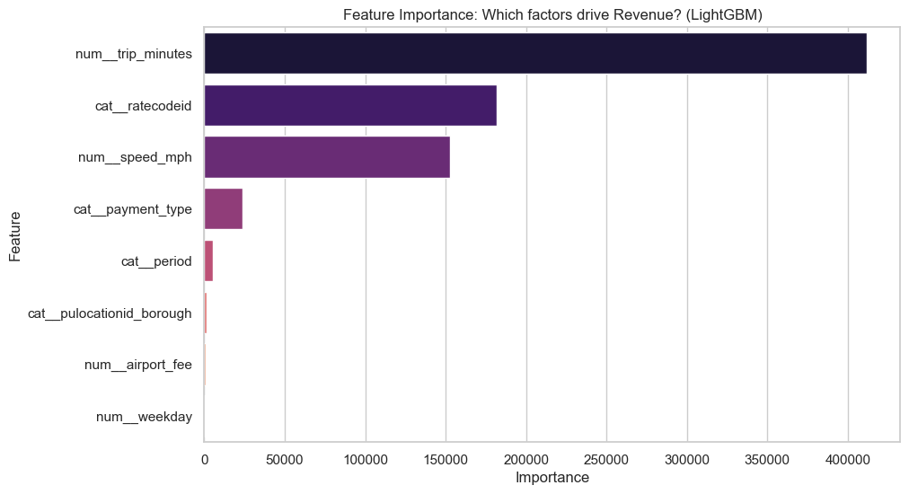

```python
# Extract feature names after preprocessing
all_feat_names = lgb_pipeline.named_steps['prep'].get_feature_names_out()

# Get the mask of features that SelectKBest actually kept
mask = lgb_pipeline.named_steps['select'].get_support()
selected_feat_names = all_feat_names[mask]

# Get importances from LightGBM
importances = lgb_pipeline.named_steps['lgbm'].feature_importances_

# Plot
fi_df = pd.DataFrame({'Feature': selected_feat_names, 'Importance': importances})
fi_df = fi_df.sort_values('Importance', ascending=False)

plt.figure(figsize=(10, 6))
sns.barplot(x='Importance',
            y='Feature',
            data=fi_df,
            hue='Feature', # Assigning hue to the y-variable satisfies the new rule
            palette='magma')
plt.title('Feature Importance: Which factors drive Revenue? (LightGBM)')
plt.show()
```

**Applying to Individual Test Scenarios (from earlier):**

```python
# Ensure categorical types are strings to avoid the earlier TypeError
for col in cat_cols:
    test_cases[col] = test_cases[col].astype(str)

# Run LightGBM predictions
test_cases['LGBM_Prediction'] = lgb_pipeline.predict(test_cases)

# Transpose for the "Human-Friendly" spec-sheet view
print("\n=== INDIVIDUAL TEST CASE RESULTS (LIGHTGBM) ===")
display(test_cases.T)
```

```
=== INDIVIDUAL TEST CASE RESULTS (LIGHTGBM) ===
```

|  | Short City Hop | Airport Run (Rush Hour) |
| --- | --- | --- |
| trip_distance | 1.2 | 18.5 |
| trip_minutes | 8.0 | 55.0 |
| speed_mph | 9.0 | 20.0 |
| passenger_count | 1 | 2 |
| pickup_hour | 14 | 17 |
| weekday | 2 | 4 |
| airport_fee | 0.0 | 1.25 |
| dolocationid_borough | 1 | 3 |
| pulocationid_borough | 2 | 1 |
| payment_type | 3 | 4 |
| period | 4 | 3 |
| ratecodeid | 5 | 2 |
| prediction | 2.002632 | 1.777517 |
| LGBM_Prediction | 1.752228 | 1.720069 |

## Conclusion

Throughout this development there was extended data wrangling activity, for both directly intended purposes and for unpredicted data cleaning tasks. Such lead to the development of data analysis and some data visualizations (both by descriptive statistics based methods and unsupervised learning). Following, predictive models based on tree methods were applied. A data set may seem quite uninteresting, yet knowledge, imagination and interest can lead to advance development.

## Reference

NYC Taxi and Limousine Commision (2024, July 1). 2023 Yellow Taxi Trip Data: NYC open data. 2023 Yellow Taxi Trip Data | NYC Open Data. https://data.cityofnewyork.us/Transportation/2023-Yellow-Taxi-Trip-Data/4b4i-vvec/about_data

Socrata Developer Portal. Socrata. (n.d.). https://dev.socrata.com/foundry/data.cityofnewyork.us/4b4i-vvec

Publisher data.cityofnewyork.us. (2025, June 21). City of New York - NYC Taxi Zones. Catalog. https://catalog.data.gov/dataset/nyc-taxi-zones-131e4

TLC rules and local laws. TLC Rules - TLC. (n.d.). https://www.nyc.gov/site/tlc/about/tlc-rules.page

Ximena. (2024, October 16). TLC NYC Taxi Zones. Kaggle. https://www.kaggle.com/datasets/mxruedag/tlc-nyc-taxi-zones?resource=download